# Study 3

## (1) Description of Data Files

The posted data for this study consists of 1 compiled, deidentified data file (total *N* recruited = 202):

- 32 responses were excluded because we could not obtain administrative data (SES and GPA) for those participants

## (2) Descriptive statistics

**Total *N*:** 170

```
## gender
## doesn't identify as either                     female                       male
##                          1                         76                         93
##                       <NA>
##                          0
```

**Percentage of sample by all races:**

```
## race
##          white    multiracial          black          asian         latino middle-eastern
##           55.3           20.6           12.9            6.5            3.5            1.2
##           <NA>
##            0.0
```

```
## race.cat
## non-stigmatized     stigmatized            <NA>
##            61.8            38.2             0.0
```

*N* in each condition: We had 3 conditions in this study: “weak” (i.e, they saw the weak LTSS figure), “strong” (i.e, they saw the malleable LTSS figure), and “control” (i.e., they were not presented with a figure).

```
## cond
##   ctrl strong   weak   <NA>
##     58     55     57      0
```

*M*s and *SD*s:

```
##              n     mean       sd      min       max
## Age        170    14.10     0.32    13.00     15.00
## income     170 87179.35 40855.37 15208.00 215104.00
## income.cat 170     4.36     1.73     1.00      8.00
## ladder     170     6.32     1.80     1.00     10.00
## persist    170     5.04     1.16     1.00      7.00
## gpa        170     3.62     0.72     1.62      4.54
```

**Alpha for inclinations to persist:** 0.88

**Correlations between income and subjective SES:**

```
##
##  Pearson's product-moment correlation
##
## data:  income and ladder
## t = 0.62566, df = 168, p-value = 0.5324
## alternative hypothesis: true correlation is not equal to 0
## 95 percent confidence interval:
##  -0.1030474  0.1972972
## sample estimates:
##        cor
## 0.04821471
```

```
##
##  Pearson's product-moment correlation
##
## data:  income.cat and ladder
## t = 0.57738, df = 168, p-value = 0.5645
## alternative hypothesis: true correlation is not equal to 0
## 95 percent confidence interval:
##  -0.1067274  0.1937184
## sample estimates:
##        cor
## 0.04450171
```

## (3) Random assignment checks

### ANOVA, *M*s, and *SD*s for income

```
##              Df Sum Sq Mean Sq F value Pr(>F)
## cond          2    4.4   2.215   0.741  0.478
## Residuals   167  499.0   2.988
```

**Descriptives for the strong condition:**

```
##     n mean   sd
## X1 55 4.16 1.81
```

**Descriptives for the weak condition:**

```
##     n mean  sd
## X1 57 4.56 1.6
```

**Descriptives for the control condition:**

```
##     n mean   sd
## X1 58 4.36 1.76
```

### ANOVA, *M*s, and *SD*s for subjective SES

```
##              Df Sum Sq Mean Sq F value Pr(>F)
## cond          2   10.2   5.096   1.592  0.207
## Residuals   167  534.7   3.202
```

**Descriptives for the strong condition:**

```
##     n mean   sd
## X1 55 6.55 1.85
```

**Descriptives for the weak condition:**

```
##     n mean   sd
## X1 57 6.44 1.65
```

**Descriptives for the control condition:**

```
##     n mean   sd
## X1 58 5.98 1.86
```

## (4) Main analyses

### Persistence analyses

#### Analyses with income

**Correlation between income and academic persistence:**

```
##
##  Pearson's product-moment correlation
##
## data:  income and persist
## t = 0.35861, df = 168, p-value = 0.7203
## alternative hypothesis: true correlation is not equal to 0
## 95 percent confidence interval:
##  -0.1233709  0.1774326
## sample estimates:
##        cor
## 0.02765691
```

**Omnibus interaction:**

```
## Single term deletions
##
## Model:
## persist ~ incomecat_c * cond
##                  Df Sum of Sq    RSS    AIC F value  Pr(>F)
## <none>                        212.13 49.637
## incomecat_c       1    2.2944 214.42 49.465  1.7738 0.18476
## cond              2    3.6937 215.82 48.571  1.4278 0.24279
## incomecat_c:cond  2    8.4510 220.58 52.278  3.2668 0.04062 *
## ---
## Signif. codes:  0 '***' 0.001 '**' 0.01 '*' 0.05 '.' 0.1 ' ' 1
```

**Denominator DFs:** 164

**Ctrl vs. weak interaction and ctrl vs. strong interaction:**

```
##        weak strong
## ctrl      0      0
## weak      1      0
## strong    0      1
```

```
##
## Call:
## lm(formula = persist ~ contrasts1 * incomecat_c)
##
## Residuals:
##     Min      1Q  Median      3Q     Max
## -3.6162 -0.7064  0.1907  0.7900  2.0543
##
## Coefficients:
##                              Estimate Standardized Std. Error t value Pr(>|t|)
## (Intercept)                   4.86830      0.00000    0.14934  32.600   <2e-16 ***
## contrasts1weak                0.12406      0.05071    0.21293   0.583   0.5609
## contrasts1strong              0.35839      0.14517    0.21474   1.669   0.0970 .
## incomecat_c                   0.31887      0.27528    0.14737   2.164   0.0319 *
## contrasts1weak:incomecat_c   -0.09794     -0.04545    0.22015  -0.445   0.6570
## contrasts1strong:incomecat_c -0.50588     -0.26045    0.20838  -2.428   0.0163 *
## ---
## Signif. codes:  0 '***' 0.001 '**' 0.01 '*' 0.05 '.' 0.1 ' ' 1
##
## Residual standard error: 1.137 on 164 degrees of freedom
## Multiple R-squared:  0.06456,    Adjusted R-squared:  0.03604
## F-statistic: 2.264 on 5 and 164 DF,  p-value: 0.05052
```

```
##                              CIs: Lower (estimate) Upper (estimate)
## (Intercept)                                   4.57             5.16
## contrasts1weak                               -0.30             0.54
## contrasts1strong                             -0.07             0.78
## incomecat_c                                   0.03             0.61
## contrasts1weak:incomecat_c                   -0.53             0.34
## contrasts1strong:incomecat_c                 -0.92            -0.09
```

**Ctrl vs. weak simple slopes and ctrl vs. strong simple slopes among lower-SES students (“contrast” terms):**

```
##        weak strong
## ctrl      0      0
## weak      1      0
## strong    0      1
```

```
##
## Call:
## lm(formula = persist ~ contrasts1 * loinc)
##
## Residuals:
##     Min      1Q  Median      3Q     Max
## -3.6162 -0.7064  0.1907  0.7900  2.0543
##
## Coefficients:
##                        Estimate Std. Error t value Pr(>|t|)
## (Intercept)             4.54943    0.20965  21.700  < 2e-16 ***
## contrasts1weak          0.22200    0.31597   0.703  0.48331
## contrasts1strong        0.86428    0.29054   2.975  0.00338 **
## loinc                   0.31887    0.14737   2.164  0.03193 *
## contrasts1weak:loinc   -0.09794    0.22015  -0.445  0.65701
## contrasts1strong:loinc -0.50588    0.20838  -2.428  0.01628 *
## ---
## Signif. codes:  0 '***' 0.001 '**' 0.01 '*' 0.05 '.' 0.1 ' ' 1
##
## Residual standard error: 1.137 on 164 degrees of freedom
## Multiple R-squared:  0.06456,    Adjusted R-squared:  0.03604
## F-statistic: 2.264 on 5 and 164 DF,  p-value: 0.05052
```

```
##                        CIs: Lower (estimate) Upper (estimate)
## (Intercept)                             4.14             4.96
## contrasts1weak                         -0.40             0.85
## contrasts1strong                        0.29             1.44
## loinc                                   0.03             0.61
## contrasts1weak:loinc                   -0.53             0.34
## contrasts1strong:loinc                 -0.92            -0.09
```

**Ctrl vs. weak simple slopes and ctrl vs. malleable simple slopes among higher-SES students (“contrast” terms):**

```
##        weak strong
## ctrl      0      0
## weak      1      0
## strong    0      1
```

```
##
## Call:
## lm(formula = persist ~ contrasts1 * hiinc)
##
## Residuals:
##     Min      1Q  Median      3Q     Max
## -3.6162 -0.7064  0.1907  0.7900  2.0543
##
## Coefficients:
##                        Estimate Standardized Std. Error t value Pr(>|t|)
## (Intercept)             5.18718      0.00000    0.20997  24.705   <2e-16 ***
## contrasts1weak          0.02612      0.01068    0.29627   0.088   0.9298
## contrasts1strong       -0.14749     -0.05974    0.30766  -0.479   0.6323
## hiinc                   0.31887      0.27528    0.14737   2.164   0.0319 *
## contrasts1weak:hiinc   -0.09794     -0.05747    0.22015  -0.445   0.6570
## contrasts1strong:hiinc -0.50588     -0.34584    0.20838  -2.428   0.0163 *
## ---
## Signif. codes:  0 '***' 0.001 '**' 0.01 '*' 0.05 '.' 0.1 ' ' 1
##
## Residual standard error: 1.137 on 164 degrees of freedom
## Multiple R-squared:  0.06456,    Adjusted R-squared:  0.03604
## F-statistic: 2.264 on 5 and 164 DF,  p-value: 0.05052
```

```
##                        CIs: Lower (estimate) Upper (estimate)
## (Intercept)                             4.77             5.60
## contrasts1weak                         -0.56             0.61
## contrasts1strong                       -0.75             0.46
## hiinc                                   0.03             0.61
## contrasts1weak:hiinc                   -0.53             0.34
## contrasts1strong:hiinc                 -0.92            -0.09
```

**Weak vs. strong interaction and weak vs. ctrl interaction (repeated from previous analyses):**

```
##        strong ctrl
## weak        0    0
## strong      1    0
## ctrl        0    1
```

```
##
## Call:
## lm(formula = persist ~ contrasts2 * incomecat_c)
##
## Residuals:
##     Min      1Q  Median      3Q     Max
## -3.6162 -0.7064  0.1907  0.7900  2.0543
##
## Coefficients:
##                              Estimate Standardized Std. Error t value Pr(>|t|)
## (Intercept)                   4.99236      0.00000    0.15179  32.890   <2e-16 ***
## contrasts2strong              0.23433      0.09492    0.21645   1.083   0.2806
## contrasts2ctrl               -0.12406     -0.05093    0.21293  -0.583   0.5609
## incomecat_c                   0.22094      0.19073    0.16355   1.351   0.1786
## contrasts2strong:incomecat_c -0.40795     -0.21002    0.22012  -1.853   0.0656 .
## contrasts2ctrl:incomecat_c    0.09794      0.05019    0.22015   0.445   0.6570
## ---
## Signif. codes:  0 '***' 0.001 '**' 0.01 '*' 0.05 '.' 0.1 ' ' 1
##
## Residual standard error: 1.137 on 164 degrees of freedom
## Multiple R-squared:  0.06456,    Adjusted R-squared:  0.03604
## F-statistic: 2.264 on 5 and 164 DF,  p-value: 0.05052
```

```
##                              CIs: Lower (estimate) Upper (estimate)
## (Intercept)                                   4.69             5.29
## contrasts2strong                             -0.19             0.66
## contrasts2ctrl                               -0.54             0.30
## incomecat_c                                  -0.10             0.54
## contrasts2strong:incomecat_c                 -0.84             0.03
## contrasts2ctrl:incomecat_c                   -0.34             0.53
```

**Weak vs. mallable simple slopes and weak vs. ctrl simple slopes (repeated) among lower-SES students (“contrast” terms):**

```
##        strong ctrl
## weak        0    0
## strong      1    0
## ctrl        0    1
```

```
##
## Call:
## lm(formula = persist ~ contrasts2 * loinc)
##
## Residuals:
##     Min      1Q  Median      3Q     Max
## -3.6162 -0.7064  0.1907  0.7900  2.0543
##
## Coefficients:
##                        Estimate Standardized Std. Error t value Pr(>|t|)
## (Intercept)             4.77143      0.00000    0.23640  20.184   <2e-16 ***
## contrasts2strong        0.64228      0.26016    0.31039   2.069   0.0401 *
## contrasts2ctrl         -0.22200     -0.09113    0.31597  -0.703   0.4833
## loinc                   0.22094      0.19073    0.16355   1.351   0.1786
## contrasts2strong:loinc -0.40795     -0.25505    0.22012  -1.853   0.0656 .
## contrasts2ctrl:loinc    0.09794      0.06427    0.22015   0.445   0.6570
## ---
## Signif. codes:  0 '***' 0.001 '**' 0.01 '*' 0.05 '.' 0.1 ' ' 1
##
## Residual standard error: 1.137 on 164 degrees of freedom
## Multiple R-squared:  0.06456,    Adjusted R-squared:  0.03604
## F-statistic: 2.264 on 5 and 164 DF,  p-value: 0.05052
```

```
##                        CIs: Lower (estimate) Upper (estimate)
## (Intercept)                             4.30             5.24
## contrasts2strong                        0.03             1.26
## contrasts2ctrl                         -0.85             0.40
## loinc                                  -0.10             0.54
## contrasts2strong:loinc                 -0.84             0.03
## contrasts2ctrl:loinc                   -0.34             0.53
```

**Weak vs. mallable simple slopes and weak vs. ctrl simple slopes (repeated) among higher-SES students (“contrast” terms):**

```
##        strong ctrl
## weak        0    0
## strong      1    0
## ctrl        0    1
```

```
##
## Call:
## lm(formula = persist ~ contrasts2 * hiinc)
##
## Residuals:
##     Min      1Q  Median      3Q     Max
## -3.6162 -0.7064  0.1907  0.7900  2.0543
##
## Coefficients:
##                        Estimate Standardized Std. Error t value Pr(>|t|)
## (Intercept)             5.21330      0.00000    0.20902  24.941   <2e-16 ***
## contrasts2strong       -0.17361     -0.07032    0.30702  -0.565   0.5725
## contrasts2ctrl         -0.02612     -0.01072    0.29627  -0.088   0.9298
## hiinc                   0.22094      0.19073    0.16355   1.351   0.1786
## contrasts2strong:hiinc -0.40795     -0.27889    0.22012  -1.853   0.0656 .
## contrasts2ctrl:hiinc    0.09794      0.06434    0.22015   0.445   0.6570
## ---
## Signif. codes:  0 '***' 0.001 '**' 0.01 '*' 0.05 '.' 0.1 ' ' 1
##
## Residual standard error: 1.137 on 164 degrees of freedom
## Multiple R-squared:  0.06456,    Adjusted R-squared:  0.03604
## F-statistic: 2.264 on 5 and 164 DF,  p-value: 0.05052
```

```
##                        CIs: Lower (estimate) Upper (estimate)
## (Intercept)                             4.80             5.63
## contrasts2strong                       -0.78             0.43
## contrasts2ctrl                         -0.61             0.56
## hiinc                                  -0.10             0.54
## contrasts2strong:hiinc                 -0.84             0.03
## contrasts2ctrl:hiinc                   -0.34             0.53
```

**Plot:**

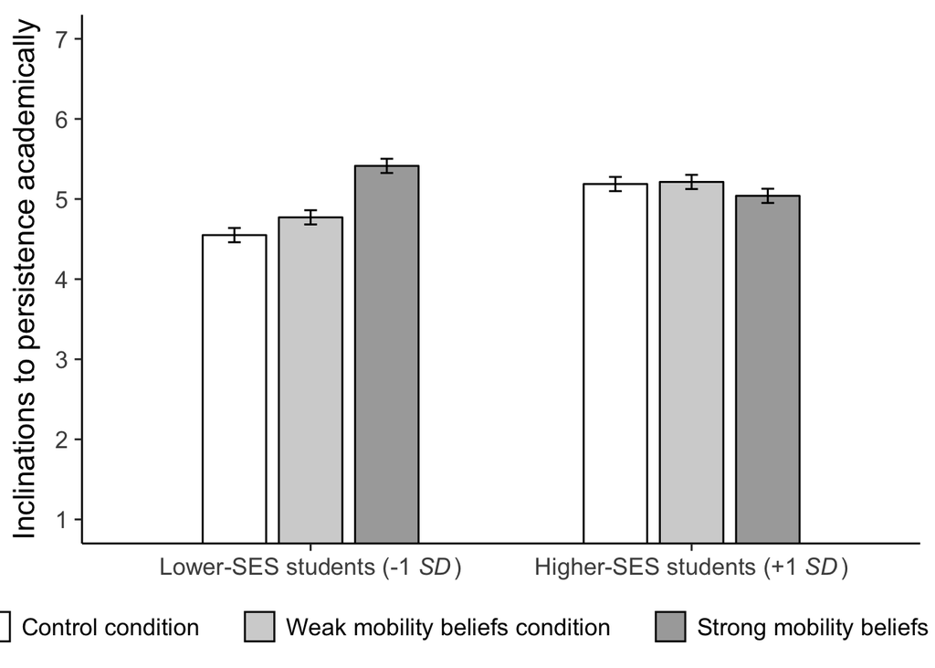

#### Analyses with income and race

##### Main effect of race

```
##
##  F test to compare two variances
##
## data:  persist by race.cat
## F = 1.0096, num df = 104, denom df = 64, p-value = 0.9805
## alternative hypothesis: true ratio of variances is not equal to 1
## 95 percent confidence interval:
##  0.6401864 1.5548238
## sample estimates:
## ratio of variances
##           1.009575
```

```
##
##  Two Sample t-test
##
## data:  persist by race.cat
## t = 1.1835, df = 168, p-value = 0.2383
## alternative hypothesis: true difference in means is not equal to 0
## 95 percent confidence interval:
##  -0.1443731  0.5766075
## sample estimates:
## mean in group non-stigmatized     mean in group stigmatized
##                      5.123810                      4.907692
```

```
##
##  Descriptive statistics by group
## group: non-stigmatized
##    vars   n mean   sd median trimmed  mad min max range  skew kurtosis   se
## X1    1 105 5.12 1.16   5.33    5.21 0.99   1   7     6 -0.78     0.46 0.11
## ---------------------------------------------------------------------------
## group: stigmatized
##    vars  n mean   sd median trimmed  mad  min max range  skew kurtosis   se
## X1    1 65 4.91 1.15   4.83    4.91 1.24 1.83   7  5.17 -0.05    -0.56 0.14
```

##### Condition x income analyses

```
## Single term deletions
##
## Model:
## persist ~ cond * incomecat_c * race.cat_c
##                             Df Sum of Sq    RSS    AIC F value  Pr(>F)
## <none>                                   200.70 52.226
## cond                         2    6.0759 206.78 53.296  2.3916 0.09479 .
## incomecat_c                  1    3.4050 204.11 53.086  2.6805 0.10357
## race.cat_c                   1    0.9281 201.63 51.010  0.7306 0.39397
## cond:incomecat_c             2    6.1584 206.86 53.363  2.4240 0.09185 .
## cond:race.cat_c              2    0.3285 201.03 48.504  0.1293 0.87880
## incomecat_c:race.cat_c       1    0.5206 201.22 50.666  0.4098 0.52298
## cond:incomecat_c:race.cat_c  2    8.8492 209.55 55.561  3.4832 0.03309 *
## ---
## Signif. codes:  0 '***' 0.001 '**' 0.01 '*' 0.05 '.' 0.1 ' ' 1
```

**Denominator DFs:** 158

**Ctrl vs. weak interaction and ctrl vs. strong interaction:**

```
##
## Call:
## lm(formula = persist ~ contrasts1 * incomecat_c * race.cat_c)
##
## Residuals:
##     Min      1Q  Median      3Q     Max
## -3.4059 -0.7002  0.0740  0.7084  2.1878
##
## Coefficients:
##                                          Estimate Standardized Std. Error t value Pr(>|t|)
## (Intercept)                              4.816427     0.000000   0.153020  31.476  < 2e-16 ***
## contrasts1weak                           0.187614     0.076688   0.216380   0.867  0.38722
## contrasts1strong                         0.473530     0.191807   0.217885   2.173  0.03125 *
## incomecat_c                              0.352135     0.303992   0.151278   2.328  0.02119 *
## race.cat_c                               0.011637     0.009793   0.162837   0.071  0.94312
## contrasts1weak:incomecat_c              -0.146757    -0.068113   0.224776  -0.653  0.51477
## contrasts1strong:incomecat_c            -0.464677    -0.239231   0.215003  -2.161  0.03218 *
## contrasts1weak:race.cat_c                0.097085     0.047392   0.225614   0.430  0.66756
## contrasts1strong:race.cat_c              0.102949     0.050490   0.226192   0.455  0.64963
## incomecat_c:race.cat_c                   0.233207     0.189502   0.150864   1.546  0.12415
## contrasts1weak:incomecat_c:race.cat_c   -0.287179    -0.124621   0.231861  -1.239  0.21734
## contrasts1strong:incomecat_c:race.cat_c -0.595798    -0.281178   0.225905  -2.637  0.00919 **
## ---
## Signif. codes:  0 '***' 0.001 '**' 0.01 '*' 0.05 '.' 0.1 ' ' 1
##
## Residual standard error: 1.127 on 158 degrees of freedom
## Multiple R-squared:  0.1149, Adjusted R-squared:  0.05332
## F-statistic: 1.865 on 11 and 158 DF,  p-value: 0.04771
```

```
##                                         2.5 % 97.5 %
## (Intercept)                              4.51   5.12
## contrasts1weak                          -0.24   0.61
## contrasts1strong                         0.04   0.90
## incomecat_c                              0.05   0.65
## race.cat_c                              -0.31   0.33
## contrasts1weak:incomecat_c              -0.59   0.30
## contrasts1strong:incomecat_c            -0.89  -0.04
## contrasts1weak:race.cat_c               -0.35   0.54
## contrasts1strong:race.cat_c             -0.34   0.55
## incomecat_c:race.cat_c                  -0.06   0.53
## contrasts1weak:incomecat_c:race.cat_c   -0.75   0.17
## contrasts1strong:incomecat_c:race.cat_c -1.04  -0.15
```

```
##        weak strong
## ctrl      0      0
## weak      1      0
## strong    0      1
```

```
##
## Call:
## lm(formula = persist ~ contrasts1 * loinc * nonstig)
##
## Residuals:
##     Min      1Q  Median      3Q     Max
## -3.4059 -0.7002  0.0740  0.7084  2.1878
##
## Coefficients:
##                                Estimate Std. Error t value Pr(>|t|)
## (Intercept)                      4.2483     0.3281  12.949  < 2e-16 ***
## contrasts1weak                   0.7089     0.4804   1.476 0.141960
## contrasts1strong                 1.6193     0.4387   3.691 0.000307 ***
## loinc                            0.5795     0.2242   2.585 0.010642 *
## nonstig                         -0.2216     0.2101  -1.055 0.293232
## contrasts1weak:loinc            -0.4267     0.3171  -1.346 0.180315
## contrasts1strong:loinc          -1.0455     0.2941  -3.554 0.000500 ***
## contrasts1weak:nonstig           0.3843     0.3165   1.214 0.226582
## contrasts1strong:nonstig         0.6987     0.2946   2.372 0.018913 *
## loinc:nonstig                    0.2332     0.1509   1.546 0.124150
## contrasts1weak:loinc:nonstig    -0.2872     0.2319  -1.239 0.217337
## contrasts1strong:loinc:nonstig  -0.5958     0.2259  -2.637 0.009190 **
## ---
## Signif. codes:  0 '***' 0.001 '**' 0.01 '*' 0.05 '.' 0.1 ' ' 1
##
## Residual standard error: 1.127 on 158 degrees of freedom
## Multiple R-squared:  0.1149, Adjusted R-squared:  0.05332
## F-statistic: 1.865 on 11 and 158 DF,  p-value: 0.04771
```

```
##                                2.5 % 97.5 %
## (Intercept)                     3.60   4.90
## contrasts1weak                 -0.24   1.66
## contrasts1strong                0.75   2.49
## loinc                           0.14   1.02
## nonstig                        -0.64   0.19
## contrasts1weak:loinc           -1.05   0.20
## contrasts1strong:loinc         -1.63  -0.46
## contrasts1weak:nonstig         -0.24   1.01
## contrasts1strong:nonstig        0.12   1.28
## loinc:nonstig                  -0.06   0.53
## contrasts1weak:loinc:nonstig   -0.75   0.17
## contrasts1strong:loinc:nonstig -1.04  -0.15
```

```
##
## Call:
## lm(formula = persist ~ contrasts1 * loinc * stig)
##
## Residuals:
##     Min      1Q  Median      3Q     Max
## -3.4059 -0.7002  0.0740  0.7084  2.1878
##
## Coefficients:
##                             Estimate Std. Error t value Pr(>|t|)
## (Intercept)                  4.68028    0.26265  17.820  < 2e-16 ***
## contrasts1weak              -0.04021    0.40606  -0.099  0.92125
## contrasts1strong             0.25707    0.38392   0.670  0.50410
## loinc                        0.12481    0.19691   0.634  0.52711
## stig                        -0.22157    0.21010  -1.055  0.29323
## contrasts1weak:loinc         0.13318    0.32044   0.416  0.67824
## contrasts1strong:loinc       0.11610    0.32082   0.362  0.71792
## contrasts1weak:stig          0.38426    0.31654   1.214  0.22658
## contrasts1strong:stig        0.69875    0.29462   2.372  0.01891 *
## loinc:stig                   0.23321    0.15086   1.546  0.12415
## contrasts1weak:loinc:stig   -0.28718    0.23186  -1.239  0.21734
## contrasts1strong:loinc:stig -0.59580    0.22590  -2.637  0.00919 **
## ---
## Signif. codes:  0 '***' 0.001 '**' 0.01 '*' 0.05 '.' 0.1 ' ' 1
##
## Residual standard error: 1.127 on 158 degrees of freedom
## Multiple R-squared:  0.1149, Adjusted R-squared:  0.05332
## F-statistic: 1.865 on 11 and 158 DF,  p-value: 0.04771
```

```
##                             2.5 % 97.5 %
## (Intercept)                  4.16   5.20
## contrasts1weak              -0.84   0.76
## contrasts1strong            -0.50   1.02
## loinc                       -0.26   0.51
## stig                        -0.64   0.19
## contrasts1weak:loinc        -0.50   0.77
## contrasts1strong:loinc      -0.52   0.75
## contrasts1weak:stig         -0.24   1.01
## contrasts1strong:stig        0.12   1.28
## loinc:stig                  -0.06   0.53
## contrasts1weak:loinc:stig   -0.75   0.17
## contrasts1strong:loinc:stig -1.04  -0.15
```

```
##        weak strong
## ctrl      0      0
## weak      1      0
## strong    0      1
```

```
##
## Call:
## lm(formula = persist ~ contrasts1 * hiinc * nonstig)
##
## Residuals:
##     Min      1Q  Median      3Q     Max
## -3.4059 -0.7002  0.0740  0.7084  2.1878
##
## Coefficients:
##                                Estimate Std. Error t value Pr(>|t|)
## (Intercept)                      5.4072     0.2767  19.543  < 2e-16 ***
## contrasts1weak                  -0.1444     0.3876  -0.373  0.70990
## contrasts1strong                -0.4716     0.4070  -1.159  0.24837
## hiinc                            0.5795     0.2242   2.585  0.01064 *
## nonstig                          0.2448     0.2333   1.050  0.29546
## contrasts1weak:hiinc            -0.4267     0.3171  -1.346  0.18031
## contrasts1strong:hiinc          -1.0455     0.2941  -3.554  0.00050 ***
## contrasts1weak:nonstig          -0.1901     0.3303  -0.575  0.56580
## contrasts1strong:nonstig        -0.4928     0.3429  -1.437  0.15263
## hiinc:nonstig                    0.2332     0.1509   1.546  0.12415
## contrasts1weak:hiinc:nonstig    -0.2872     0.2319  -1.239  0.21734
## contrasts1strong:hiinc:nonstig  -0.5958     0.2259  -2.637  0.00919 **
## ---
## Signif. codes:  0 '***' 0.001 '**' 0.01 '*' 0.05 '.' 0.1 ' ' 1
##
## Residual standard error: 1.127 on 158 degrees of freedom
## Multiple R-squared:  0.1149, Adjusted R-squared:  0.05332
## F-statistic: 1.865 on 11 and 158 DF,  p-value: 0.04771
```

```
##                                2.5 % 97.5 %
## (Intercept)                     4.86   5.95
## contrasts1weak                 -0.91   0.62
## contrasts1strong               -1.28   0.33
## hiinc                           0.14   1.02
## nonstig                        -0.22   0.71
## contrasts1weak:hiinc           -1.05   0.20
## contrasts1strong:hiinc         -1.63  -0.46
## contrasts1weak:nonstig         -0.84   0.46
## contrasts1strong:nonstig       -1.17   0.18
## hiinc:nonstig                  -0.06   0.53
## contrasts1weak:hiinc:nonstig   -0.75   0.17
## contrasts1strong:hiinc:nonstig -1.04  -0.15
```

```
##
## Call:
## lm(formula = persist ~ contrasts1 * hiinc * stig)
##
## Residuals:
##     Min      1Q  Median      3Q     Max
## -3.4059 -0.7002  0.0740  0.7084  2.1878
##
## Coefficients:
##                             Estimate Std. Error t value Pr(>|t|)
## (Intercept)                   4.9299     0.3454  14.272  < 2e-16 ***
## contrasts1weak                0.2262     0.4912   0.460  0.64587
## contrasts1strong              0.4893     0.5077   0.964  0.33664
## hiinc                         0.1248     0.1969   0.634  0.52711
## stig                          0.2448     0.2333   1.050  0.29546
## contrasts1weak:hiinc          0.1332     0.3204   0.416  0.67824
## contrasts1strong:hiinc        0.1161     0.3208   0.362  0.71792
## contrasts1weak:stig          -0.1901     0.3303  -0.575  0.56580
## contrasts1strong:stig        -0.4928     0.3429  -1.437  0.15263
## hiinc:stig                    0.2332     0.1509   1.546  0.12415
## contrasts1weak:hiinc:stig    -0.2872     0.2319  -1.239  0.21734
## contrasts1strong:hiinc:stig  -0.5958     0.2259  -2.637  0.00919 **
## ---
## Signif. codes:  0 '***' 0.001 '**' 0.01 '*' 0.05 '.' 0.1 ' ' 1
##
## Residual standard error: 1.127 on 158 degrees of freedom
## Multiple R-squared:  0.1149, Adjusted R-squared:  0.05332
## F-statistic: 1.865 on 11 and 158 DF,  p-value: 0.04771
```

```
##                             2.5 % 97.5 %
## (Intercept)                  4.25   5.61
## contrasts1weak              -0.74   1.20
## contrasts1strong            -0.51   1.49
## hiinc                       -0.26   0.51
## stig                        -0.22   0.71
## contrasts1weak:hiinc        -0.50   0.77
## contrasts1strong:hiinc      -0.52   0.75
## contrasts1weak:stig         -0.84   0.46
## contrasts1strong:stig       -1.17   0.18
## hiinc:stig                  -0.06   0.53
## contrasts1weak:hiinc:stig   -0.75   0.17
## contrasts1strong:hiinc:stig -1.04  -0.15
```

**Weak vs. strong interaction and weak vs. ctrl interaction (repeated from previous analyses):**

```
##        strong ctrl
## weak        0    0
## strong      1    0
## ctrl        0    1
```

```
##
## Call:
## lm(formula = persist ~ contrasts2 * incomecat_c * race.cat_c)
##
## Residuals:
##     Min      1Q  Median      3Q     Max
## -3.4059 -0.7002  0.0740  0.7084  2.1878
##
## Coefficients:
##                                          Estimate Standardized Std. Error t value Pr(>|t|)
## (Intercept)                              5.004041     0.000000   0.152987  32.709   <2e-16 ***
## contrasts2strong                         0.285916     0.115812   0.217862   1.312    0.191
## contrasts2ctrl                          -0.187614    -0.077015   0.216380  -0.867    0.387
## incomecat_c                              0.205378     0.177299   0.166251   1.235    0.219
## race.cat_c                               0.108722     0.091492   0.156160   0.696    0.487
## contrasts2strong:incomecat_c            -0.317921    -0.163676   0.225789  -1.408    0.161
## contrasts2ctrl:incomecat_c               0.146757     0.075209   0.224776   0.653    0.515
## contrasts2strong:race.cat_c              0.005865     0.002876   0.221434   0.026    0.979
## contrasts2ctrl:race.cat_c               -0.097085    -0.046294   0.225614  -0.430    0.668
## incomecat_c:race.cat_c                  -0.053972    -0.043857   0.176068  -0.307    0.760
## contrasts2strong:incomecat_c:race.cat_c -0.308619    -0.145648   0.243461  -1.268    0.207
## contrasts2ctrl:incomecat_c:race.cat_c    0.287179     0.147262   0.231861   1.239    0.217
## ---
## Signif. codes:  0 '***' 0.001 '**' 0.01 '*' 0.05 '.' 0.1 ' ' 1
##
## Residual standard error: 1.127 on 158 degrees of freedom
## Multiple R-squared:  0.1149, Adjusted R-squared:  0.05332
## F-statistic: 1.865 on 11 and 158 DF,  p-value: 0.04771
```

```
##                                         2.5 % 97.5 %
## (Intercept)                              4.70   5.31
## contrasts2strong                        -0.14   0.72
## contrasts2ctrl                          -0.61   0.24
## incomecat_c                             -0.12   0.53
## race.cat_c                              -0.20   0.42
## contrasts2strong:incomecat_c            -0.76   0.13
## contrasts2ctrl:incomecat_c              -0.30   0.59
## contrasts2strong:race.cat_c             -0.43   0.44
## contrasts2ctrl:race.cat_c               -0.54   0.35
## incomecat_c:race.cat_c                  -0.40   0.29
## contrasts2strong:incomecat_c:race.cat_c -0.79   0.17
## contrasts2ctrl:incomecat_c:race.cat_c   -0.17   0.75
```

**Weak vs. mallable simple slopes and weak vs. ctrl simple slopes (repeated) among lower-SES students (“contrast” terms):**

```
##        strong ctrl
## weak        0    0
## strong      1    0
## ctrl        0    1
```

```
##
## Call:
## lm(formula = persist ~ contrasts2 * loinc * nonstig)
##
## Residuals:
##     Min      1Q  Median      3Q     Max
## -3.4059 -0.7002  0.0740  0.7084  2.1878
##
## Coefficients:
##                                Estimate Std. Error t value Pr(>|t|)
## (Intercept)                     4.95726    0.35085  14.129   <2e-16 ***
## contrasts2strong                0.91039    0.45595   1.997   0.0476 *
## contrasts2ctrl                 -0.70895    0.48035  -1.476   0.1420
## loinc                           0.15277    0.22424   0.681   0.4967
## nonstig                         0.16269    0.23676   0.687   0.4930
## contrasts2strong:loinc         -0.61876    0.29418  -2.103   0.0370 *
## contrasts2ctrl:loinc            0.42670    0.31707   1.346   0.1803
## contrasts2strong:nonstig        0.31448    0.31419   1.001   0.3184
## contrasts2ctrl:nonstig         -0.38426    0.31654  -1.214   0.2266
## loinc:nonstig                  -0.05397    0.17607  -0.307   0.7596
## contrasts2strong:loinc:nonstig -0.30862    0.24346  -1.268   0.2068
## contrasts2ctrl:loinc:nonstig    0.28718    0.23186   1.239   0.2173
## ---
## Signif. codes:  0 '***' 0.001 '**' 0.01 '*' 0.05 '.' 0.1 ' ' 1
##
## Residual standard error: 1.127 on 158 degrees of freedom
## Multiple R-squared:  0.1149, Adjusted R-squared:  0.05332
## F-statistic: 1.865 on 11 and 158 DF,  p-value: 0.04771
```

```
##                                2.5 % 97.5 %
## (Intercept)                     4.26   5.65
## contrasts2strong                0.01   1.81
## contrasts2ctrl                 -1.66   0.24
## loinc                          -0.29   0.60
## nonstig                        -0.30   0.63
## contrasts2strong:loinc         -1.20  -0.04
## contrasts2ctrl:loinc           -0.20   1.05
## contrasts2strong:nonstig       -0.31   0.94
## contrasts2ctrl:nonstig         -1.01   0.24
## loinc:nonstig                  -0.40   0.29
## contrasts2strong:loinc:nonstig -0.79   0.17
## contrasts2ctrl:loinc:nonstig   -0.17   0.75
```

```
##
## Call:
## lm(formula = persist ~ contrasts2 * loinc * stig)
##
## Residuals:
##     Min      1Q  Median      3Q     Max
## -3.4059 -0.7002  0.0740  0.7084  2.1878
##
## Coefficients:
##                             Estimate Std. Error t value Pr(>|t|)
## (Intercept)                  4.64007    0.30968  14.983   <2e-16 ***
## contrasts2strong             0.29728    0.41751   0.712    0.477
## contrasts2ctrl               0.04021    0.40606   0.099    0.921
## loinc                        0.25799    0.25280   1.021    0.309
## stig                         0.16269    0.23676   0.687    0.493
## contrasts2strong:loinc      -0.01708    0.35786  -0.048    0.962
## contrasts2ctrl:loinc        -0.13318    0.32044  -0.416    0.678
## contrasts2strong:stig        0.31448    0.31419   1.001    0.318
## contrasts2ctrl:stig         -0.38426    0.31654  -1.214    0.227
## loinc:stig                  -0.05397    0.17607  -0.307    0.760
## contrasts2strong:loinc:stig -0.30862    0.24346  -1.268    0.207
## contrasts2ctrl:loinc:stig    0.28718    0.23186   1.239    0.217
## ---
## Signif. codes:  0 '***' 0.001 '**' 0.01 '*' 0.05 '.' 0.1 ' ' 1
##
## Residual standard error: 1.127 on 158 degrees of freedom
## Multiple R-squared:  0.1149, Adjusted R-squared:  0.05332
## F-statistic: 1.865 on 11 and 158 DF,  p-value: 0.04771
```

```
##                             2.5 % 97.5 %
## (Intercept)                  4.03   5.25
## contrasts2strong            -0.53   1.12
## contrasts2ctrl              -0.76   0.84
## loinc                       -0.24   0.76
## stig                        -0.30   0.63
## contrasts2strong:loinc      -0.72   0.69
## contrasts2ctrl:loinc        -0.77   0.50
## contrasts2strong:stig       -0.31   0.94
## contrasts2ctrl:stig         -1.01   0.24
## loinc:stig                  -0.40   0.29
## contrasts2strong:loinc:stig -0.79   0.17
## contrasts2ctrl:loinc:stig   -0.17   0.75
```

**Weak vs. mallable simple slopes and weak vs. ctrl simple slopes (repeated) among higher-SES students (“contrast” terms):**

```
##        strong ctrl
## weak        0    0
## strong      1    0
## ctrl        0    1
```

```
##
## Call:
## lm(formula = persist ~ contrasts2 * hiinc * nonstig)
##
## Residuals:
##     Min      1Q  Median      3Q     Max
## -3.4059 -0.7002  0.0740  0.7084  2.1878
##
## Coefficients:
##                                Estimate Std. Error t value Pr(>|t|)
## (Intercept)                     5.26279    0.27145  19.387   <2e-16 ***
## contrasts2strong               -0.32713    0.40349  -0.811    0.419
## contrasts2ctrl                  0.14445    0.38761   0.373    0.710
## hiinc                           0.15277    0.22424   0.681    0.497
## nonstig                         0.05475    0.23391   0.234    0.815
## contrasts2strong:hiinc         -0.61876    0.29418  -2.103    0.037 *
## contrasts2ctrl:hiinc            0.42670    0.31707   1.346    0.180
## contrasts2strong:nonstig       -0.30275    0.34336  -0.882    0.379
## contrasts2ctrl:nonstig          0.19009    0.33034   0.575    0.566
## hiinc:nonstig                  -0.05397    0.17607  -0.307    0.760
## contrasts2strong:hiinc:nonstig -0.30862    0.24346  -1.268    0.207
## contrasts2ctrl:hiinc:nonstig    0.28718    0.23186   1.239    0.217
## ---
## Signif. codes:  0 '***' 0.001 '**' 0.01 '*' 0.05 '.' 0.1 ' ' 1
##
## Residual standard error: 1.127 on 158 degrees of freedom
## Multiple R-squared:  0.1149, Adjusted R-squared:  0.05332
## F-statistic: 1.865 on 11 and 158 DF,  p-value: 0.04771
```

```
##                                2.5 % 97.5 %
## (Intercept)                     4.73   5.80
## contrasts2strong               -1.12   0.47
## contrasts2ctrl                 -0.62   0.91
## hiinc                          -0.29   0.60
## nonstig                        -0.41   0.52
## contrasts2strong:hiinc         -1.20  -0.04
## contrasts2ctrl:hiinc           -0.20   1.05
## contrasts2strong:nonstig       -0.98   0.38
## contrasts2ctrl:nonstig         -0.46   0.84
## hiinc:nonstig                  -0.40   0.29
## contrasts2strong:hiinc:nonstig -0.79   0.17
## contrasts2ctrl:hiinc:nonstig   -0.17   0.75
```

```
##
## Call:
## lm(formula = persist ~ contrasts2 * hiinc * stig)
##
## Residuals:
##     Min      1Q  Median      3Q     Max
## -3.4059 -0.7002  0.0740  0.7084  2.1878
##
## Coefficients:
##                             Estimate Std. Error t value Pr(>|t|)
## (Intercept)                  5.15605    0.34930  14.761   <2e-16 ***
## contrasts2strong             0.26312    0.51033   0.516    0.607
## contrasts2ctrl              -0.22616    0.49125  -0.460    0.646
## hiinc                        0.25799    0.25280   1.021    0.309
## stig                         0.05475    0.23391   0.234    0.815
## contrasts2strong:hiinc      -0.01708    0.35786  -0.048    0.962
## contrasts2ctrl:hiinc        -0.13318    0.32044  -0.416    0.678
## contrasts2strong:stig       -0.30275    0.34336  -0.882    0.379
## contrasts2ctrl:stig          0.19009    0.33034   0.575    0.566
## hiinc:stig                  -0.05397    0.17607  -0.307    0.760
## contrasts2strong:hiinc:stig -0.30862    0.24346  -1.268    0.207
## contrasts2ctrl:hiinc:stig    0.28718    0.23186   1.239    0.217
## ---
## Signif. codes:  0 '***' 0.001 '**' 0.01 '*' 0.05 '.' 0.1 ' ' 1
##
## Residual standard error: 1.127 on 158 degrees of freedom
## Multiple R-squared:  0.1149, Adjusted R-squared:  0.05332
## F-statistic: 1.865 on 11 and 158 DF,  p-value: 0.04771
```

```
##                             2.5 % 97.5 %
## (Intercept)                  4.47   5.85
## contrasts2strong            -0.74   1.27
## contrasts2ctrl              -1.20   0.74
## hiinc                       -0.24   0.76
## stig                        -0.41   0.52
## contrasts2strong:hiinc      -0.72   0.69
## contrasts2ctrl:hiinc        -0.77   0.50
## contrasts2strong:stig       -0.98   0.38
## contrasts2ctrl:stig         -0.46   0.84
## hiinc:stig                  -0.40   0.29
## contrasts2strong:hiinc:stig -0.79   0.17
## contrasts2ctrl:hiinc:stig   -0.17   0.75
```

#### Analyses with income and gender

##### Main effect of gender

```
##
##  F test to compare two variances
##
## data:  persist by gender2
## F = 1.0407, num df = 75, denom df = 92, p-value = 0.8506
## alternative hypothesis: true ratio of variances is not equal to 1
## 95 percent confidence interval:
##  0.6774065 1.6144195
## sample estimates:
## ratio of variances
##           1.040698
```

```
##
##  Two Sample t-test
##
## data:  persist by gender2
## t = 0.12302, df = 167, p-value = 0.9022
## alternative hypothesis: true difference in means is not equal to 0
## 95 percent confidence interval:
##  -0.3335468  0.3778780
## sample estimates:
## mean in group female   mean in group male
##             5.052632             5.030466
```

```
##
##  Descriptive statistics by group
## group: female
##    vars  n mean   sd median trimmed  mad  min max range  skew kurtosis   se
## X1    1 76 5.05 1.18      5     5.1 1.48 1.83   7  5.17 -0.33    -0.71 0.14
## ---------------------------------------------------------------------------
## group: male
##    vars  n mean   sd median trimmed  mad min max range  skew kurtosis   se
## X1    1 93 5.03 1.15   5.17    5.08 0.99   1   7     6 -0.63     0.48 0.12
```

##### Condition x SES analyses

```
## Single term deletions
##
## Model:
## persist ~ cond * incomecat_c * gender_c
##                           Df Sum of Sq    RSS    AIC F value  Pr(>F)
## <none>                                 202.31 54.404
## cond                       2    4.5803 206.89 54.188  1.7772 0.17249
## incomecat_c                1    2.9318 205.24 54.836  2.2752 0.13347
## gender_c                   1    0.1322 202.44 52.514  0.1026 0.74919
## cond:incomecat_c           2    7.2671 209.58 56.368  2.8198 0.06264 .
## cond:gender_c              2    4.0207 206.33 53.730  1.5601 0.21336
## incomecat_c:gender_c       1    0.0338 202.34 52.432  0.0263 0.87149
## cond:incomecat_c:gender_c  2    6.5240 208.84 55.768  2.5314 0.08279 .
## ---
## Signif. codes:  0 '***' 0.001 '**' 0.01 '*' 0.05 '.' 0.1 ' ' 1
```

**Denominator DFs:** 157

**Ctrl vs. weak interaction and ctrl vs. strong interaction:**

```
##
## Call:
## lm(formula = persist ~ contrasts1 * incomecat_c * gender_c)
##
## Residuals:
##     Min      1Q  Median      3Q     Max
## -3.4354 -0.7345  0.1133  0.7276  2.2093
##
## Coefficients:
##                                       Estimate Standardized Std. Error t value Pr(>|t|)
## (Intercept)                            4.87787      0.00000    0.14927  32.678   <2e-16 ***
## contrasts1weak                         0.15862      0.06474    0.21588   0.735   0.4636
## contrasts1strong                       0.40979      0.16496    0.21828   1.877   0.0623 .
## incomecat_c                            0.34479      0.29762    0.14788   2.332   0.0210 *
## gender_c                               0.01847      0.01586    0.15061   0.123   0.9026
## contrasts1weak:incomecat_c            -0.14271     -0.06624    0.22221  -0.642   0.5217
## contrasts1strong:incomecat_c          -0.48779     -0.25108    0.21018  -2.321   0.0216 *
## contrasts1weak:gender_c                0.12361      0.06237    0.21526   0.574   0.5666
## contrasts1strong:gender_c             -0.26546     -0.12697    0.22177  -1.197   0.2331
## incomecat_c:gender_c                   0.26217      0.22441    0.14721   1.781   0.0769 .
## contrasts1weak:incomecat_c:gender_c   -0.40450     -0.18512    0.22286  -1.815   0.0714 .
## contrasts1strong:incomecat_c:gender_c -0.42564     -0.21694    0.21109  -2.016   0.0455 *
## ---
## Signif. codes:  0 '***' 0.001 '**' 0.01 '*' 0.05 '.' 0.1 ' ' 1
##
## Residual standard error: 1.135 on 157 degrees of freedom
##   (1 observation deleted due to missingness)
## Multiple R-squared:  0.1078, Adjusted R-squared:  0.04528
## F-statistic: 1.724 on 11 and 157 DF,  p-value: 0.07252
```

```
##                                       2.5 % 97.5 %
## (Intercept)                            4.58   5.17
## contrasts1weak                        -0.27   0.59
## contrasts1strong                      -0.02   0.84
## incomecat_c                            0.05   0.64
## gender_c                              -0.28   0.32
## contrasts1weak:incomecat_c            -0.58   0.30
## contrasts1strong:incomecat_c          -0.90  -0.07
## contrasts1weak:gender_c               -0.30   0.55
## contrasts1strong:gender_c             -0.70   0.17
## incomecat_c:gender_c                  -0.03   0.55
## contrasts1weak:incomecat_c:gender_c   -0.84   0.04
## contrasts1strong:incomecat_c:gender_c -0.84  -0.01
```

**Ctrl vs. weak simple slopes and ctrl vs. strong simple slopes among lower-SES male and female students (“contrast” terms):**

```
##        weak strong
## ctrl      0      0
## weak      1      0
## strong    0      1
```

```
##
## Call:
## lm(formula = persist ~ contrasts1 * loinc * men)
##
## Residuals:
##     Min      1Q  Median      3Q     Max
## -3.4354 -0.7345  0.1133  0.7276  2.2093
##
## Coefficients:
##                            Estimate Std. Error t value Pr(>|t|)
## (Intercept)                  4.2899     0.2956  14.512  < 2e-16 ***
## contrasts1weak               0.8283     0.4771   1.736  0.08453 .
## contrasts1strong             1.0574     0.4165   2.539  0.01210 *
## loinc                        0.6064     0.2182   2.779  0.00611 **
## men                         -0.2437     0.2110  -1.155  0.24992
## contrasts1weak:loinc        -0.5464     0.3178  -1.719  0.08751 .
## contrasts1strong:loinc      -0.9125     0.2987  -3.055  0.00264 **
## contrasts1weak:men           0.5281     0.3191   1.655  0.09990 .
## contrasts1strong:men         0.1602     0.2925   0.548  0.58475
## loinc:men                    0.2622     0.1472   1.781  0.07686 .
## contrasts1weak:loinc:men    -0.4045     0.2229  -1.815  0.07143 .
## contrasts1strong:loinc:men  -0.4256     0.2111  -2.016  0.04546 *
## ---
## Signif. codes:  0 '***' 0.001 '**' 0.01 '*' 0.05 '.' 0.1 ' ' 1
##
## Residual standard error: 1.135 on 157 degrees of freedom
##   (1 observation deleted due to missingness)
## Multiple R-squared:  0.1078, Adjusted R-squared:  0.04528
## F-statistic: 1.724 on 11 and 157 DF,  p-value: 0.07252
```

```
##                            2.5 % 97.5 %
## (Intercept)                 3.71   4.87
## contrasts1weak             -0.11   1.77
## contrasts1strong            0.23   1.88
## loinc                       0.18   1.04
## men                        -0.66   0.17
## contrasts1weak:loinc       -1.17   0.08
## contrasts1strong:loinc     -1.50  -0.32
## contrasts1weak:men         -0.10   1.16
## contrasts1strong:men       -0.42   0.74
## loinc:men                  -0.03   0.55
## contrasts1weak:loinc:men   -0.84   0.04
## contrasts1strong:loinc:men -0.84  -0.01
```

```
##
## Call:
## lm(formula = persist ~ contrasts1 * loinc * women)
##
## Residuals:
##     Min      1Q  Median      3Q     Max
## -3.4354 -0.7345  0.1133  0.7276  2.2093
##
## Coefficients:
##                              Estimate Std. Error t value Pr(>|t|)
## (Intercept)                   4.77627    0.29878  15.986   <2e-16 ***
## contrasts1weak               -0.22566    0.42583  -0.530   0.5969
## contrasts1strong              0.73773    0.40866   1.805   0.0730 .
## loinc                         0.08318    0.19823   0.420   0.6754
## women                        -0.24370    0.21102  -1.155   0.2499
## contrasts1weak:loinc          0.26093    0.31097   0.839   0.4027
## contrasts1strong:loinc       -0.06305    0.29645  -0.213   0.8318
## contrasts1weak:women          0.52811    0.31908   1.655   0.0999 .
## contrasts1strong:women        0.16019    0.29253   0.548   0.5847
## loinc:women                   0.26217    0.14721   1.781   0.0769 .
## contrasts1weak:loinc:women   -0.40450    0.22286  -1.815   0.0714 .
## contrasts1strong:loinc:women -0.42564    0.21109  -2.016   0.0455 *
## ---
## Signif. codes:  0 '***' 0.001 '**' 0.01 '*' 0.05 '.' 0.1 ' ' 1
##
## Residual standard error: 1.135 on 157 degrees of freedom
##   (1 observation deleted due to missingness)
## Multiple R-squared:  0.1078, Adjusted R-squared:  0.04528
## F-statistic: 1.724 on 11 and 157 DF,  p-value: 0.07252
```

```
##                              2.5 % 97.5 %
## (Intercept)                   4.19   5.37
## contrasts1weak               -1.07   0.62
## contrasts1strong             -0.07   1.54
## loinc                        -0.31   0.47
## women                        -0.66   0.17
## contrasts1weak:loinc         -0.35   0.88
## contrasts1strong:loinc       -0.65   0.52
## contrasts1weak:women         -0.10   1.16
## contrasts1strong:women       -0.42   0.74
## loinc:women                  -0.03   0.55
## contrasts1weak:loinc:women   -0.84   0.04
## contrasts1strong:loinc:women -0.84  -0.01
```

**Ctrl vs. weak simple slopes and ctrl vs. malleable simple slopes among higher-SES male and female students (“contrast” terms):**

```
##        weak strong
## ctrl      0      0
## weak      1      0
## strong    0      1
```

```
##
## Call:
## lm(formula = persist ~ contrasts1 * hiinc * men)
##
## Residuals:
##     Min      1Q  Median      3Q     Max
## -3.4354 -0.7345  0.1133  0.7276  2.2093
##
## Coefficients:
##                            Estimate Std. Error t value Pr(>|t|)
## (Intercept)                  5.5027     0.3069  17.933  < 2e-16 ***
## contrasts1weak              -0.2644     0.4176  -0.633  0.52758
## contrasts1strong            -0.7676     0.4214  -1.821  0.07043 .
## hiinc                        0.6064     0.2182   2.779  0.00611 **
## men                          0.2806     0.2102   1.335  0.18373
## contrasts1weak:hiinc        -0.5464     0.3178  -1.719  0.08751 .
## contrasts1strong:hiinc      -0.9125     0.2987  -3.055  0.00264 **
## contrasts1weak:men          -0.2809     0.3003  -0.935  0.35109
## contrasts1strong:men        -0.6911     0.3192  -2.165  0.03191 *
## hiinc:men                    0.2622     0.1472   1.781  0.07686 .
## contrasts1weak:hiinc:men    -0.4045     0.2229  -1.815  0.07143 .
## contrasts1strong:hiinc:men  -0.4256     0.2111  -2.016  0.04546 *
## ---
## Signif. codes:  0 '***' 0.001 '**' 0.01 '*' 0.05 '.' 0.1 ' ' 1
##
## Residual standard error: 1.135 on 157 degrees of freedom
##   (1 observation deleted due to missingness)
## Multiple R-squared:  0.1078, Adjusted R-squared:  0.04528
## F-statistic: 1.724 on 11 and 157 DF,  p-value: 0.07252
```

```
##                            2.5 % 97.5 %
## (Intercept)                 4.90   6.11
## contrasts1weak             -1.09   0.56
## contrasts1strong           -1.60   0.06
## hiinc                       0.18   1.04
## men                        -0.13   0.70
## contrasts1weak:hiinc       -1.17   0.08
## contrasts1strong:hiinc     -1.50  -0.32
## contrasts1weak:men         -0.87   0.31
## contrasts1strong:men       -1.32  -0.06
## hiinc:men                  -0.03   0.55
## contrasts1weak:hiinc:men   -0.84   0.04
## contrasts1strong:hiinc:men -0.84  -0.01
```

```
##
## Call:
## lm(formula = persist ~ contrasts1 * hiinc * women)
##
## Residuals:
##     Min      1Q  Median      3Q     Max
## -3.4354 -0.7345  0.1133  0.7276  2.2093
##
## Coefficients:
##                              Estimate Std. Error t value Pr(>|t|)
## (Intercept)                   4.94262    0.28714  17.213   <2e-16 ***
## contrasts1weak                0.29619    0.42773   0.692   0.4897
## contrasts1strong              0.61163    0.47177   1.296   0.1967
## hiinc                         0.08318    0.19823   0.420   0.6754
## women                         0.28063    0.21017   1.335   0.1837
## contrasts1weak:hiinc          0.26093    0.31097   0.839   0.4027
## contrasts1strong:hiinc       -0.06305    0.29645  -0.213   0.8318
## contrasts1weak:women         -0.28088    0.30033  -0.935   0.3511
## contrasts1strong:women       -0.69110    0.31923  -2.165   0.0319 *
## hiinc:women                   0.26217    0.14721   1.781   0.0769 .
## contrasts1weak:hiinc:women   -0.40450    0.22286  -1.815   0.0714 .
## contrasts1strong:hiinc:women -0.42564    0.21109  -2.016   0.0455 *
## ---
## Signif. codes:  0 '***' 0.001 '**' 0.01 '*' 0.05 '.' 0.1 ' ' 1
##
## Residual standard error: 1.135 on 157 degrees of freedom
##   (1 observation deleted due to missingness)
## Multiple R-squared:  0.1078, Adjusted R-squared:  0.04528
## F-statistic: 1.724 on 11 and 157 DF,  p-value: 0.07252
```

```
##                              2.5 % 97.5 %
## (Intercept)                   4.38   5.51
## contrasts1weak               -0.55   1.14
## contrasts1strong             -0.32   1.54
## hiinc                        -0.31   0.47
## women                        -0.13   0.70
## contrasts1weak:hiinc         -0.35   0.88
## contrasts1strong:hiinc       -0.65   0.52
## contrasts1weak:women         -0.87   0.31
## contrasts1strong:women       -1.32  -0.06
## hiinc:women                  -0.03   0.55
## contrasts1weak:hiinc:women   -0.84   0.04
## contrasts1strong:hiinc:women -0.84  -0.01
```

**Weak vs. strong interaction and weak vs. ctrl interaction (repeated from previous analyses):**

```
##        strong ctrl
## weak        0    0
## strong      1    0
## ctrl        0    1
```

```
##
## Call:
## lm(formula = persist ~ contrasts2 * incomecat_c * gender_c)
##
## Residuals:
##     Min      1Q  Median      3Q     Max
## -3.4354 -0.7345  0.1133  0.7276  2.2093
##
## Coefficients:
##                                       Estimate Standardized Std. Error t value Pr(>|t|)
## (Intercept)                            5.03649      0.00000    0.15596  32.293   <2e-16 ***
## contrasts2strong                       0.25117      0.10111    0.22291   1.127   0.2616
## contrasts2ctrl                        -0.15862     -0.06501    0.21588  -0.735   0.4636
## incomecat_c                            0.20207      0.17443    0.16586   1.218   0.2249
## gender_c                               0.14208      0.12204    0.15380   0.924   0.3570
## contrasts2strong:incomecat_c          -0.34508     -0.17762    0.22319  -1.546   0.1241
## contrasts2ctrl:incomecat_c             0.14271      0.07314    0.22221   0.642   0.5217
## contrasts2strong:gender_c             -0.38907     -0.18610    0.22395  -1.737   0.0843 .
## contrasts2ctrl:gender_c               -0.12361     -0.06195    0.21526  -0.574   0.5666
## incomecat_c:gender_c                  -0.14233     -0.12183    0.16732  -0.851   0.3963
## contrasts2strong:incomecat_c:gender_c -0.02115     -0.01078    0.22558  -0.094   0.9254
## contrasts2ctrl:incomecat_c:gender_c    0.40450      0.20820    0.22286   1.815   0.0714 .
## ---
## Signif. codes:  0 '***' 0.001 '**' 0.01 '*' 0.05 '.' 0.1 ' ' 1
##
## Residual standard error: 1.135 on 157 degrees of freedom
##   (1 observation deleted due to missingness)
## Multiple R-squared:  0.1078, Adjusted R-squared:  0.04528
## F-statistic: 1.724 on 11 and 157 DF,  p-value: 0.07252
```

```
##                                       2.5 % 97.5 %
## (Intercept)                            4.73   5.34
## contrasts2strong                      -0.19   0.69
## contrasts2ctrl                        -0.59   0.27
## incomecat_c                           -0.13   0.53
## gender_c                              -0.16   0.45
## contrasts2strong:incomecat_c          -0.79   0.10
## contrasts2ctrl:incomecat_c            -0.30   0.58
## contrasts2strong:gender_c             -0.83   0.05
## contrasts2ctrl:gender_c               -0.55   0.30
## incomecat_c:gender_c                  -0.47   0.19
## contrasts2strong:incomecat_c:gender_c -0.47   0.42
## contrasts2ctrl:incomecat_c:gender_c   -0.04   0.84
```

**Weak vs. mallable simple slopes and weak vs. ctrl simple slopes (repeated) among lower-SES students (“contrast” terms):**

```
##        strong ctrl
## weak        0    0
## strong      1    0
## ctrl        0    1
```

```
##
## Call:
## lm(formula = persist ~ contrasts2 * loinc * men)
##
## Residuals:
##     Min      1Q  Median      3Q     Max
## -3.4354 -0.7345  0.1133  0.7276  2.2093
##
## Coefficients:
##                            Estimate Std. Error t value Pr(>|t|)
## (Intercept)                 5.11823    0.37454  13.665   <2e-16 ***
## contrasts2strong            0.22910    0.47579   0.482   0.6308
## contrasts2ctrl             -0.82833    0.47715  -1.736   0.0845 .
## loinc                       0.06004    0.23101   0.260   0.7953
## men                         0.28441    0.23933   1.188   0.2365
## contrasts2strong:loinc     -0.36618    0.30818  -1.188   0.2365
## contrasts2ctrl:loinc        0.54636    0.31775   1.719   0.0875 .
## contrasts2strong:men       -0.36792    0.31356  -1.173   0.2424
## contrasts2ctrl:men         -0.52811    0.31908  -1.655   0.0999 .
## loinc:men                  -0.14233    0.16732  -0.851   0.3963
## contrasts2strong:loinc:men -0.02115    0.22558  -0.094   0.9254
## contrasts2ctrl:loinc:men    0.40450    0.22286   1.815   0.0714 .
## ---
## Signif. codes:  0 '***' 0.001 '**' 0.01 '*' 0.05 '.' 0.1 ' ' 1
##
## Residual standard error: 1.135 on 157 degrees of freedom
##   (1 observation deleted due to missingness)
## Multiple R-squared:  0.1078, Adjusted R-squared:  0.04528
## F-statistic: 1.724 on 11 and 157 DF,  p-value: 0.07252
```

```
##                            2.5 % 97.5 %
## (Intercept)                 4.38   5.86
## contrasts2strong           -0.71   1.17
## contrasts2ctrl             -1.77   0.11
## loinc                      -0.40   0.52
## men                        -0.19   0.76
## contrasts2strong:loinc     -0.97   0.24
## contrasts2ctrl:loinc       -0.08   1.17
## contrasts2strong:men       -0.99   0.25
## contrasts2ctrl:men         -1.16   0.10
## loinc:men                  -0.47   0.19
## contrasts2strong:loinc:men -0.47   0.42
## contrasts2ctrl:loinc:men   -0.04   0.84
```

```
##
## Call:
## lm(formula = persist ~ contrasts2 * loinc * women)
##
## Residuals:
##     Min      1Q  Median      3Q     Max
## -3.4354 -0.7345  0.1133  0.7276  2.2093
##
## Coefficients:
##                              Estimate Std. Error t value Pr(>|t|)
## (Intercept)                   4.55061    0.30341  14.998   <2e-16 ***
## contrasts2strong              0.96339    0.41206   2.338   0.0206 *
## contrasts2ctrl                0.22566    0.42583   0.530   0.5969
## loinc                         0.34410    0.23961   1.436   0.1530
## women                         0.28441    0.23933   1.188   0.2365
## contrasts2strong:loinc       -0.32398    0.32557  -0.995   0.3212
## contrasts2ctrl:loinc         -0.26093    0.31097  -0.839   0.4027
## contrasts2strong:women       -0.36792    0.31356  -1.173   0.2424
## contrasts2ctrl:women         -0.52811    0.31908  -1.655   0.0999 .
## loinc:women                  -0.14233    0.16732  -0.851   0.3963
## contrasts2strong:loinc:women -0.02115    0.22558  -0.094   0.9254
## contrasts2ctrl:loinc:women    0.40450    0.22286   1.815   0.0714 .
## ---
## Signif. codes:  0 '***' 0.001 '**' 0.01 '*' 0.05 '.' 0.1 ' ' 1
##
## Residual standard error: 1.135 on 157 degrees of freedom
##   (1 observation deleted due to missingness)
## Multiple R-squared:  0.1078, Adjusted R-squared:  0.04528
## F-statistic: 1.724 on 11 and 157 DF,  p-value: 0.07252
```

```
##                              2.5 % 97.5 %
## (Intercept)                   3.95   5.15
## contrasts2strong              0.15   1.78
## contrasts2ctrl               -0.62   1.07
## loinc                        -0.13   0.82
## women                        -0.19   0.76
## contrasts2strong:loinc       -0.97   0.32
## contrasts2ctrl:loinc         -0.88   0.35
## contrasts2strong:women       -0.99   0.25
## contrasts2ctrl:women         -1.16   0.10
## loinc:women                  -0.47   0.19
## contrasts2strong:loinc:women -0.47   0.42
## contrasts2ctrl:loinc:women   -0.04   0.84
```

**Weak vs. mallable simple slopes and weak vs. ctrl simple slopes (repeated) among higher-SES students (“contrast” terms):**

```
##        strong ctrl
## weak        0    0
## strong      1    0
## ctrl        0    1
```

```
##
## Call:
## lm(formula = persist ~ contrasts2 * hiinc * men)
##
## Residuals:
##     Min      1Q  Median      3Q     Max
## -3.4354 -0.7345  0.1133  0.7276  2.2093
##
## Coefficients:
##                              Estimate Std. Error t value Pr(>|t|)
## (Intercept)                 5.2383149  0.2832398  18.494   <2e-16 ***
## contrasts2strong           -0.5032579  0.4045657  -1.244   0.2154
## contrasts2ctrl              0.2643865  0.4175935   0.633   0.5276
## hiinc                       0.0600416  0.2310149   0.260   0.7953
## men                        -0.0002489  0.2145316  -0.001   0.9991
## contrasts2strong:hiinc     -0.3661810  0.3081798  -1.188   0.2365
## contrasts2ctrl:hiinc        0.5463561  0.3177542   1.719   0.0875 .
## contrasts2strong:men       -0.4102178  0.3221157  -1.274   0.2047
## contrasts2ctrl:men          0.2808837  0.3003287   0.935   0.3511
## hiinc:men                  -0.1423318  0.1673240  -0.851   0.3963
## contrasts2strong:hiinc:men -0.0211470  0.2255790  -0.094   0.9254
## contrasts2ctrl:hiinc:men    0.4044971  0.2228610   1.815   0.0714 .
## ---
## Signif. codes:  0 '***' 0.001 '**' 0.01 '*' 0.05 '.' 0.1 ' ' 1
##
## Residual standard error: 1.135 on 157 degrees of freedom
##   (1 observation deleted due to missingness)
## Multiple R-squared:  0.1078, Adjusted R-squared:  0.04528
## F-statistic: 1.724 on 11 and 157 DF,  p-value: 0.07252
```

```
##                            2.5 % 97.5 %
## (Intercept)                 4.68   5.80
## contrasts2strong           -1.30   0.30
## contrasts2ctrl             -0.56   1.09
## hiinc                      -0.40   0.52
## men                        -0.42   0.42
## contrasts2strong:hiinc     -0.97   0.24
## contrasts2ctrl:hiinc       -0.08   1.17
## contrasts2strong:men       -1.05   0.23
## contrasts2ctrl:men         -0.31   0.87
## hiinc:men                  -0.47   0.19
## contrasts2strong:hiinc:men -0.47   0.42
## contrasts2ctrl:hiinc:men   -0.04   0.84
```

```
##
## Call:
## lm(formula = persist ~ contrasts2 * hiinc * women)
##
## Residuals:
##     Min      1Q  Median      3Q     Max
## -3.4354 -0.7345  0.1133  0.7276  2.2093
##
## Coefficients:
##                                Estimate Std. Error t value Pr(>|t|)
## (Intercept)                   5.2388117  0.3170261  16.525   <2e-16 ***
## contrasts2strong              0.3154420  0.4905370   0.643   0.5211
## contrasts2ctrl               -0.2961925  0.4277304  -0.692   0.4897
## hiinc                         0.3441030  0.2396051   1.436   0.1530
## women                        -0.0002489  0.2145316  -0.001   0.9991
## contrasts2strong:hiinc       -0.3239765  0.3255729  -0.995   0.3212
## contrasts2ctrl:hiinc         -0.2609268  0.3109744  -0.839   0.4027
## contrasts2strong:women       -0.4102178  0.3221157  -1.274   0.2047
## contrasts2ctrl:women          0.2808837  0.3003287   0.935   0.3511
## hiinc:women                  -0.1423318  0.1673240  -0.851   0.3963
## contrasts2strong:hiinc:women -0.0211470  0.2255790  -0.094   0.9254
## contrasts2ctrl:hiinc:women    0.4044971  0.2228610   1.815   0.0714 .
## ---
## Signif. codes:  0 '***' 0.001 '**' 0.01 '*' 0.05 '.' 0.1 ' ' 1
##
## Residual standard error: 1.135 on 157 degrees of freedom
##   (1 observation deleted due to missingness)
## Multiple R-squared:  0.1078, Adjusted R-squared:  0.04528
## F-statistic: 1.724 on 11 and 157 DF,  p-value: 0.07252
```

```
##                              2.5 % 97.5 %
## (Intercept)                   4.61   5.86
## contrasts2strong             -0.65   1.28
## contrasts2ctrl               -1.14   0.55
## hiinc                        -0.13   0.82
## women                        -0.42   0.42
## contrasts2strong:hiinc       -0.97   0.32
## contrasts2ctrl:hiinc         -0.88   0.35
## contrasts2strong:women       -1.05   0.23
## contrasts2ctrl:women         -0.31   0.87
## hiinc:women                  -0.47   0.19
## contrasts2strong:hiinc:women -0.47   0.42
## contrasts2ctrl:hiinc:women   -0.04   0.84
```

#### Analyses with subjective SES

**Correlation between subjective SES and academic persistence:**

```
##
##  Pearson's product-moment correlation
##
## data:  ladder and persist
## t = 1.2513, df = 168, p-value = 0.2126
## alternative hypothesis: true correlation is not equal to 0
## 95 percent confidence interval:
##  -0.05522104  0.24309028
## sample estimates:
##        cor
## 0.09609189
```

**Omnibus interaction:**

```
## Single term deletions
##
## Model:
## persist ~ ladder_c * cond
##               Df Sum of Sq    RSS    AIC F value Pr(>F)
## <none>                     220.91 56.530
## ladder_c       1    1.5620 222.47 55.728  1.1596 0.2831
## cond           2    3.6140 224.52 55.288  1.3415 0.2643
## ladder_c:cond  2    0.2588 221.16 52.729  0.0961 0.9085
```

**Denominator DFs:** 164

#### Analyses with subjective SES and race

**Omnibus interaction:**

```
## Single term deletions
##
## Model:
## persist ~ ladder_c * cond * race.cat_c
##                          Df Sum of Sq    RSS    AIC F value Pr(>F)
## <none>                                218.25 66.476
## ladder_c                  1    0.5241 218.78 64.883  0.3794 0.5388
## cond                      2    3.8587 222.11 65.455  1.3967 0.2504
## race.cat_c                1    1.3399 219.59 65.516  0.9700 0.3262
## ladder_c:cond             2    0.2747 218.53 62.689  0.0994 0.9054
## ladder_c:race.cat_c       1    0.3345 218.59 64.736  0.2422 0.6233
## cond:race.cat_c           2    0.3761 218.63 62.768  0.1361 0.8728
## ladder_c:cond:race.cat_c  2    0.3786 218.63 62.770  0.1370 0.8721
```

**Denominator DFs:** 158

#### Analyses with subjective SES and gender

**Omnibus interaction:**

```
## Single term deletions
##
## Model:
## persist ~ ladder_c * cond * gender_c
##                        Df Sum of Sq    RSS    AIC F value Pr(>F)
## <none>                              214.92 64.621
## ladder_c                1    1.7142 216.63 63.964  1.2522 0.2648
## cond                    2    4.4487 219.37 64.084  1.6249 0.2002
## gender_c                1    0.1455 215.06 62.736  0.1063 0.7448
## ladder_c:cond           2    0.1884 215.11 60.769  0.0688 0.9335
## ladder_c:gender_c       1    0.2825 215.20 62.843  0.2064 0.6503
## cond:gender_c           2    4.3831 219.30 64.033  1.6010 0.2050
## ladder_c:cond:gender_c  2    1.0226 215.94 61.423  0.3735 0.6889
```

**Denominator DFs:** 157

### GPA analyses

#### Analysis with income

**Correlation between income and GPA:**

```
##
##  Pearson's product-moment correlation
##
## data:  income and gpa
## t = 2.0193, df = 168, p-value = 0.04505
## alternative hypothesis: true correlation is not equal to 0
## 95 percent confidence interval:
##  0.003498617 0.297552098
## sample estimates:
##       cor
## 0.1539318
```

**Omnibus interaction:**

```
## Single term deletions
##
## Model:
## gpa ~ incomecat_c * cond
##                  Df Sum of Sq    RSS     AIC F value Pr(>F)
## <none>                        84.739 -106.36
## incomecat_c       1   1.11937 85.858 -106.13  2.1664 0.1430
## cond              2   0.28192 85.021 -109.79  0.2728 0.7616
## incomecat_c:cond  2   1.07833 85.817 -108.21  1.0435 0.3546
```

**Denominator DFs:** 164

#### Analysis with income and race

##### Main effect of race

```
##
##  F test to compare two variances
##
## data:  gpa by race.cat
## F = 0.53585, num df = 104, denom df = 64, p-value = 0.0046
## alternative hypothesis: true ratio of variances is not equal to 1
## 95 percent confidence interval:
##  0.3397875 0.8252435
## sample estimates:
## ratio of variances
##          0.5358455
```

```
##
##  Welch Two Sample t-test
##
## data:  gpa by race.cat
## t = 6.0061, df = 106.3, p-value = 2.692e-08
## alternative hypothesis: true difference in means is not equal to 0
## 95 percent confidence interval:
##  0.4404195 0.8744318
## sample estimates:
## mean in group non-stigmatized     mean in group stigmatized
##                      3.871533                      3.214108
```

```
##
##  Descriptive statistics by group
## group: non-stigmatized
##    vars   n mean   sd median trimmed  mad  min  max range  skew kurtosis   se
## X1    1 105 3.87 0.56   4.02    3.96 0.47 1.64 4.54   2.9 -1.44     1.95 0.05
## ---------------------------------------------------------------------------
## group: stigmatized
##    vars  n mean   sd median trimmed  mad  min  max range  skew kurtosis   se
## X1    1 65 3.21 0.76   3.23    3.25 0.82 1.62 4.45  2.83 -0.34    -0.86 0.09
```

##### Condition x income analysis

**Omnibus interaction:**

```
## Single term deletions
##
## Model:
## gpa ~ incomecat_c * cond * race.cat_c
##                             Df Sum of Sq    RSS     AIC F value    Pr(>F)
## <none>                                   66.614 -135.27
## incomecat_c                  1    0.2415 66.855 -136.66  0.5728    0.4503
## cond                         2    0.7579 67.372 -137.35  0.8989    0.4091
## race.cat_c                   1   16.0180 82.632 -100.64 37.9929 5.682e-09 ***
## incomecat_c:cond             2    0.6489 67.263 -137.62  0.7695    0.4650
## incomecat_c:race.cat_c       1    0.0745 66.688 -137.08  0.1767    0.6748
## cond:race.cat_c              2    0.7189 67.333 -137.45  0.8526    0.4282
## incomecat_c:cond:race.cat_c  2    1.1623 67.776 -136.33  1.3784    0.2550
## ---
## Signif. codes:  0 '***' 0.001 '**' 0.01 '*' 0.05 '.' 0.1 ' ' 1
```

**Denominator DFs:** 158

#### Analysis with income and gender

##### Main effect of gender

```
##
##  F test to compare two variances
##
## data:  gpa by gender2
## F = 0.63159, num df = 75, denom df = 92, p-value = 0.04036
## alternative hypothesis: true ratio of variances is not equal to 1
## 95 percent confidence interval:
##  0.4111143 0.9797822
## sample estimates:
## ratio of variances
##          0.6315937
```

```
##
##  Welch Two Sample t-test
##
## data:  gpa by gender2
## t = 3.1707, df = 166.88, p-value = 0.00181
## alternative hypothesis: true difference in means is not equal to 0
## 95 percent confidence interval:
##  0.1268001 0.5452694
## sample estimates:
## mean in group female   mean in group male
##             3.800784             3.464749
```

```
##
##  Descriptive statistics by group
## group: female
##    vars  n mean   sd median trimmed mad min  max range  skew kurtosis   se
## X1    1 76  3.8 0.61   4.03    3.88 0.5   2 4.54  2.54 -1.01     0.14 0.07
## ---------------------------------------------------------------------------
## group: male
##    vars  n mean   sd median trimmed  mad  min  max range  skew kurtosis   se
## X1    1 93 3.46 0.77   3.65    3.55 0.73 1.62 4.48  2.86 -0.78    -0.36 0.08
```

##### Condition x income analyses

**Omnibus interaction:**

```
## Single term deletions
##
## Model:
## gpa ~ incomecat_c * cond * gender_c
##                           Df Sum of Sq    RSS     AIC F value   Pr(>F)
## <none>                                 76.325 -110.34
## incomecat_c                1    1.9652 78.290 -108.04  4.0424 0.046083 *
## cond                       2    0.1477 76.472 -114.01  0.1519 0.859211
## gender_c                   1    4.7525 81.077 -102.13  9.7760 0.002107 **
## incomecat_c:cond           2    0.7150 77.040 -112.76  0.7354 0.480969
## incomecat_c:gender_c       1    0.2646 76.589 -111.75  0.5442 0.461802
## cond:gender_c              2    0.4821 76.807 -113.28  0.4958 0.610035
## incomecat_c:cond:gender_c  2    2.8064 79.131 -108.24  2.8864 0.058742 .
## ---
## Signif. codes:  0 '***' 0.001 '**' 0.01 '*' 0.05 '.' 0.1 ' ' 1
```

**Denominator DFs:** 157

**Ctrl vs. weak interaction and ctrl vs. strong interaction:**

```
##
## Call:
## lm(formula = gpa ~ contrasts1 * incomecat_c * gender_c)
##
## Residuals:
##     Min      1Q  Median      3Q     Max
## -1.8926 -0.4271  0.1634  0.5225  0.9963
##
## Coefficients:
##                                        Estimate Standardized Std. Error t value Pr(>|t|)
## (Intercept)                            3.603254     0.000000   0.091686  39.300   <2e-16 ***
## contrasts1weak                         0.072313     0.047694   0.132600   0.545   0.5863
## contrasts1strong                       0.025142     0.016355   0.134073   0.188   0.8515
## incomecat_c                            0.202214     0.282061   0.090832   2.226   0.0274 *
## gender_c                              -0.138819    -0.192678   0.092506  -1.501   0.1355
## contrasts1weak:incomecat_c            -0.143416    -0.107563   0.136488  -1.051   0.2950
## contrasts1strong:incomecat_c          -0.132587    -0.110279   0.129094  -1.027   0.3060
## contrasts1weak:gender_c                0.011454     0.009339   0.132218   0.087   0.9311
## contrasts1strong:gender_c             -0.113293    -0.087566   0.136215  -0.832   0.4068
## incomecat_c:gender_c                   0.141692     0.195988   0.090417   1.567   0.1191
## contrasts1weak:incomecat_c:gender_c   -0.288541    -0.213383   0.136885  -2.108   0.0366 *
## contrasts1strong:incomecat_c:gender_c -0.258584    -0.212973   0.129654  -1.994   0.0478 *
## ---
## Signif. codes:  0 '***' 0.001 '**' 0.01 '*' 0.05 '.' 0.1 ' ' 1
##
## Residual standard error: 0.6972 on 157 degrees of freedom
##   (1 observation deleted due to missingness)
## Multiple R-squared:  0.1211, Adjusted R-squared:  0.05948
## F-statistic: 1.966 on 11 and 157 DF,  p-value: 0.03517
```

```
##                                       2.5 % 97.5 %
## (Intercept)                            3.42   3.78
## contrasts1weak                        -0.19   0.33
## contrasts1strong                      -0.24   0.29
## incomecat_c                            0.02   0.38
## gender_c                              -0.32   0.04
## contrasts1weak:incomecat_c            -0.41   0.13
## contrasts1strong:incomecat_c          -0.39   0.12
## contrasts1weak:gender_c               -0.25   0.27
## contrasts1strong:gender_c             -0.38   0.16
## incomecat_c:gender_c                  -0.04   0.32
## contrasts1weak:incomecat_c:gender_c   -0.56  -0.02
## contrasts1strong:incomecat_c:gender_c -0.51   0.00
```

**Ctrl vs. weak simple slopes and ctrl vs. strong simple slopes among lower-SES male and female students (“contrast” terms):**

```
##        weak strong
## ctrl      0      0
## weak      1      0
## strong    0      1
```

```
##
## Call:
## lm(formula = gpa ~ contrasts1 * loinc * men)
##
## Residuals:
##     Min      1Q  Median      3Q     Max
## -1.8926 -0.4271  0.1634  0.5225  0.9963
##
## Coefficients:
##                            Estimate Std. Error t value Pr(>|t|)
## (Intercept)                 3.12112    0.18157  17.189   <2e-16 ***
## contrasts1weak              0.51509    0.29307   1.758   0.0808 .
## contrasts1strong            0.30271    0.25583   1.183   0.2385
## loinc                       0.34361    0.13401   2.564   0.0113 *
## men                        -0.28051    0.12961  -2.164   0.0320 *
## contrasts1weak:loinc       -0.43135    0.19517  -2.210   0.0285 *
## contrasts1strong:loinc     -0.39062    0.18345  -2.129   0.0348 *
## contrasts1weak:men          0.30000    0.19598   1.531   0.1279
## contrasts1strong:men        0.14529    0.17968   0.809   0.4200
## loinc:men                   0.14169    0.09042   1.567   0.1191
## contrasts1weak:loinc:men   -0.28854    0.13689  -2.108   0.0366 *
## contrasts1strong:loinc:men -0.25858    0.12965  -1.994   0.0478 *
## ---
## Signif. codes:  0 '***' 0.001 '**' 0.01 '*' 0.05 '.' 0.1 ' ' 1
##
## Residual standard error: 0.6972 on 157 degrees of freedom
##   (1 observation deleted due to missingness)
## Multiple R-squared:  0.1211, Adjusted R-squared:  0.05948
## F-statistic: 1.966 on 11 and 157 DF,  p-value: 0.03517
```

```
##                            2.5 % 97.5 %
## (Intercept)                 2.76   3.48
## contrasts1weak             -0.06   1.09
## contrasts1strong           -0.20   0.81
## loinc                       0.08   0.61
## men                        -0.54  -0.02
## contrasts1weak:loinc       -0.82  -0.05
## contrasts1strong:loinc     -0.75  -0.03
## contrasts1weak:men         -0.09   0.69
## contrasts1strong:men       -0.21   0.50
## loinc:men                  -0.04   0.32
## contrasts1weak:loinc:men   -0.56  -0.02
## contrasts1strong:loinc:men -0.51   0.00
```

```
##
## Call:
## lm(formula = gpa ~ contrasts1 * loinc * women)
##
## Residuals:
##     Min      1Q  Median      3Q     Max
## -1.8926 -0.4271  0.1634  0.5225  0.9963
##
## Coefficients:
##                              Estimate Std. Error t value Pr(>|t|)
## (Intercept)                   3.68096    0.18352  20.058   <2e-16 ***
## contrasts1weak               -0.08363    0.26155  -0.320   0.7496
## contrasts1strong              0.01274    0.25101   0.051   0.9596
## loinc                         0.06082    0.12176   0.500   0.6181
## women                        -0.28051    0.12961  -2.164   0.0320 *
## contrasts1weak:loinc          0.14451    0.19101   0.757   0.4504
## contrasts1strong:loinc        0.12545    0.18208   0.689   0.4919
## contrasts1weak:women          0.30000    0.19598   1.531   0.1279
## contrasts1strong:women        0.14529    0.17968   0.809   0.4200
## loinc:women                   0.14169    0.09042   1.567   0.1191
## contrasts1weak:loinc:women   -0.28854    0.13689  -2.108   0.0366 *
## contrasts1strong:loinc:women -0.25858    0.12965  -1.994   0.0478 *
## ---
## Signif. codes:  0 '***' 0.001 '**' 0.01 '*' 0.05 '.' 0.1 ' ' 1
##
## Residual standard error: 0.6972 on 157 degrees of freedom
##   (1 observation deleted due to missingness)
## Multiple R-squared:  0.1211, Adjusted R-squared:  0.05948
## F-statistic: 1.966 on 11 and 157 DF,  p-value: 0.03517
```

```
##                              2.5 % 97.5 %
## (Intercept)                   3.32   4.04
## contrasts1weak               -0.60   0.43
## contrasts1strong             -0.48   0.51
## loinc                        -0.18   0.30
## women                        -0.54  -0.02
## contrasts1weak:loinc         -0.23   0.52
## contrasts1strong:loinc       -0.23   0.49
## contrasts1weak:women         -0.09   0.69
## contrasts1strong:women       -0.21   0.50
## loinc:women                  -0.04   0.32
## contrasts1weak:loinc:women   -0.56  -0.02
## contrasts1strong:loinc:women -0.51   0.00
```

**Ctrl vs. weak simple slopes and ctrl vs. malleable simple slopes among higher-SES male and female students (“contrast” terms):**

```
##        weak strong
## ctrl      0      0
## weak      1      0
## strong    0      1
```

```
##
## Call:
## lm(formula = gpa ~ contrasts1 * hiinc * men)
##
## Residuals:
##     Min      1Q  Median      3Q     Max
## -1.8926 -0.4271  0.1634  0.5225  0.9963
##
## Coefficients:
##                             Estimate Std. Error t value Pr(>|t|)
## (Intercept)                 3.808335   0.188476  20.206   <2e-16 ***
## contrasts1weak             -0.347604   0.256494  -1.355   0.1773
## contrasts1strong           -0.478535   0.258854  -1.849   0.0664 .
## hiinc                       0.343606   0.134006   2.564   0.0113 *
## men                         0.002873   0.129093   0.022   0.9823
## contrasts1weak:hiinc       -0.431347   0.195171  -2.210   0.0285 *
## contrasts1strong:hiinc     -0.390624   0.183452  -2.129   0.0348 *
## contrasts1weak:men         -0.277087   0.184467  -1.502   0.1351
## contrasts1strong:men       -0.371877   0.196077  -1.897   0.0597 .
## hiinc:men                   0.141692   0.090417   1.567   0.1191
## contrasts1weak:hiinc:men   -0.288541   0.136885  -2.108   0.0366 *
## contrasts1strong:hiinc:men -0.258584   0.129654  -1.994   0.0478 *
## ---
## Signif. codes:  0 '***' 0.001 '**' 0.01 '*' 0.05 '.' 0.1 ' ' 1
##
## Residual standard error: 0.6972 on 157 degrees of freedom
##   (1 observation deleted due to missingness)
## Multiple R-squared:  0.1211, Adjusted R-squared:  0.05948
## F-statistic: 1.966 on 11 and 157 DF,  p-value: 0.03517
```

```
##                            2.5 % 97.5 %
## (Intercept)                 3.44   4.18
## contrasts1weak             -0.85   0.16
## contrasts1strong           -0.99   0.03
## hiinc                       0.08   0.61
## men                        -0.25   0.26
## contrasts1weak:hiinc       -0.82  -0.05
## contrasts1strong:hiinc     -0.75  -0.03
## contrasts1weak:men         -0.64   0.09
## contrasts1strong:men       -0.76   0.02
## hiinc:men                  -0.04   0.32
## contrasts1weak:hiinc:men   -0.56  -0.02
## contrasts1strong:hiinc:men -0.51   0.00
```

```
##
## Call:
## lm(formula = gpa ~ contrasts1 * hiinc * women)
##
## Residuals:
##     Min      1Q  Median      3Q     Max
## -1.8926 -0.4271  0.1634  0.5225  0.9963
##
## Coefficients:
##                               Estimate Std. Error t value Pr(>|t|)
## (Intercept)                   3.802601   0.176365  21.561   <2e-16 ***
## contrasts1weak                0.205397   0.262720   0.782   0.4355
## contrasts1strong              0.263645   0.289771   0.910   0.3643
## hiinc                         0.060822   0.121756   0.500   0.6181
## women                         0.002873   0.129093   0.022   0.9823
## contrasts1weak:hiinc          0.144514   0.191006   0.757   0.4504
## contrasts1strong:hiinc        0.125451   0.182084   0.689   0.4919
## contrasts1weak:women         -0.277087   0.184467  -1.502   0.1351
## contrasts1strong:women       -0.371877   0.196077  -1.897   0.0597 .
## hiinc:women                   0.141692   0.090417   1.567   0.1191
## contrasts1weak:hiinc:women   -0.288541   0.136885  -2.108   0.0366 *
## contrasts1strong:hiinc:women -0.258584   0.129654  -1.994   0.0478 *
## ---
## Signif. codes:  0 '***' 0.001 '**' 0.01 '*' 0.05 '.' 0.1 ' ' 1
##
## Residual standard error: 0.6972 on 157 degrees of freedom
##   (1 observation deleted due to missingness)
## Multiple R-squared:  0.1211, Adjusted R-squared:  0.05948
## F-statistic: 1.966 on 11 and 157 DF,  p-value: 0.03517
```

```
##                              2.5 % 97.5 %
## (Intercept)                   3.45   4.15
## contrasts1weak               -0.31   0.72
## contrasts1strong             -0.31   0.84
## hiinc                        -0.18   0.30
## women                        -0.25   0.26
## contrasts1weak:hiinc         -0.23   0.52
## contrasts1strong:hiinc       -0.23   0.49
## contrasts1weak:women         -0.64   0.09
## contrasts1strong:women       -0.76   0.02
## hiinc:women                  -0.04   0.32
## contrasts1weak:hiinc:women   -0.56  -0.02
## contrasts1strong:hiinc:women -0.51   0.00
```

**Weak vs. strong interaction and weak vs. ctrl interaction (repeated from previous analyses):**

```
##        strong ctrl
## weak        0    0
## strong      1    0
## ctrl        0    1
```

```
##
## Call:
## lm(formula = gpa ~ contrasts2 * incomecat_c * gender_c)
##
## Residuals:
##     Min      1Q  Median      3Q     Max
## -1.8926 -0.4271  0.1634  0.5225  0.9963
##
## Coefficients:
##                                        Estimate Standardized Std. Error t value Pr(>|t|)
## (Intercept)                            3.675567     0.000000   0.095794  38.370   <2e-16 ***
## contrasts2strong                      -0.047171    -0.030685   0.136915  -0.345   0.7309
## contrasts2ctrl                        -0.072313    -0.047895   0.132600  -0.545   0.5863
## incomecat_c                            0.058798     0.082015   0.101876   0.577   0.5647
## gender_c                              -0.127365    -0.176779   0.094468  -1.348   0.1795
## contrasts2strong:incomecat_c           0.010830     0.009007   0.137090   0.079   0.9371
## contrasts2ctrl:incomecat_c             0.143416     0.118771   0.136488   1.051   0.2950
## contrasts2strong:gender_c             -0.124747    -0.096419   0.137555  -0.907   0.3659
## contrasts2ctrl:gender_c               -0.011454    -0.009276   0.132218  -0.087   0.9311
## incomecat_c:gender_c                  -0.146849    -0.203121   0.102773  -1.429   0.1550
## contrasts2strong:incomecat_c:gender_c  0.029957     0.024673   0.138555   0.216   0.8291
## contrasts2ctrl:incomecat_c:gender_c    0.288541     0.239995   0.136885   2.108   0.0366 *
## ---
## Signif. codes:  0 '***' 0.001 '**' 0.01 '*' 0.05 '.' 0.1 ' ' 1
##
## Residual standard error: 0.6972 on 157 degrees of freedom
##   (1 observation deleted due to missingness)
## Multiple R-squared:  0.1211, Adjusted R-squared:  0.05948
## F-statistic: 1.966 on 11 and 157 DF,  p-value: 0.03517
```

```
##                                       2.5 % 97.5 %
## (Intercept)                            3.49   3.86
## contrasts2strong                      -0.32   0.22
## contrasts2ctrl                        -0.33   0.19
## incomecat_c                           -0.14   0.26
## gender_c                              -0.31   0.06
## contrasts2strong:incomecat_c          -0.26   0.28
## contrasts2ctrl:incomecat_c            -0.13   0.41
## contrasts2strong:gender_c             -0.40   0.15
## contrasts2ctrl:gender_c               -0.27   0.25
## incomecat_c:gender_c                  -0.35   0.06
## contrasts2strong:incomecat_c:gender_c -0.24   0.30
## contrasts2ctrl:incomecat_c:gender_c    0.02   0.56
```

**Weak vs. mallable simple slopes and weak vs. ctrl simple slopes (repeated) among lower-SES students (“contrast” terms):**

```
##        strong ctrl
## weak        0    0
## strong      1    0
## ctrl        0    1
```

```
##
## Call:
## lm(formula = gpa ~ contrasts2 * loinc * men)
##
## Residuals:
##     Min      1Q  Median      3Q     Max
## -1.8926 -0.4271  0.1634  0.5225  0.9963
##
## Coefficients:
##                            Estimate Std. Error t value Pr(>|t|)
## (Intercept)                 3.63621    0.23005  15.806   <2e-16 ***
## contrasts2strong           -0.21238    0.29224  -0.727   0.4685
## contrasts2ctrl             -0.51509    0.29307  -1.758   0.0808 .
## loinc                      -0.08774    0.14189  -0.618   0.5372
## men                         0.01948    0.14700   0.133   0.8947
## contrasts2strong:loinc      0.04072    0.18929   0.215   0.8299
## contrasts2ctrl:loinc        0.43135    0.19517   2.210   0.0285 *
## contrasts2strong:men       -0.15470    0.19260  -0.803   0.4230
## contrasts2ctrl:men         -0.30000    0.19598  -1.531   0.1279
## loinc:men                  -0.14685    0.10277  -1.429   0.1550
## contrasts2strong:loinc:men  0.02996    0.13855   0.216   0.8291
## contrasts2ctrl:loinc:men    0.28854    0.13689   2.108   0.0366 *
## ---
## Signif. codes:  0 '***' 0.001 '**' 0.01 '*' 0.05 '.' 0.1 ' ' 1
##
## Residual standard error: 0.6972 on 157 degrees of freedom
##   (1 observation deleted due to missingness)
## Multiple R-squared:  0.1211, Adjusted R-squared:  0.05948
## F-statistic: 1.966 on 11 and 157 DF,  p-value: 0.03517
```

```
##                            2.5 % 97.5 %
## (Intercept)                 3.18   4.09
## contrasts2strong           -0.79   0.36
## contrasts2ctrl             -1.09   0.06
## loinc                      -0.37   0.19
## men                        -0.27   0.31
## contrasts2strong:loinc     -0.33   0.41
## contrasts2ctrl:loinc        0.05   0.82
## contrasts2strong:men       -0.54   0.23
## contrasts2ctrl:men         -0.69   0.09
## loinc:men                  -0.35   0.06
## contrasts2strong:loinc:men -0.24   0.30
## contrasts2ctrl:loinc:men    0.02   0.56
```

```
##
## Call:
## lm(formula = gpa ~ contrasts2 * loinc * women)
##
## Residuals:
##     Min      1Q  Median      3Q     Max
## -1.8926 -0.4271  0.1634  0.5225  0.9963
##
## Coefficients:
##                              Estimate Std. Error t value Pr(>|t|)
## (Intercept)                   3.59733    0.18636  19.303   <2e-16 ***
## contrasts2strong              0.09638    0.25310   0.381   0.7039
## contrasts2ctrl                0.08363    0.26155   0.320   0.7496
## loinc                         0.20534    0.14717   1.395   0.1649
## women                         0.01948    0.14700   0.133   0.8947
## contrasts2strong:loinc       -0.01906    0.19997  -0.095   0.9242
## contrasts2ctrl:loinc         -0.14451    0.19101  -0.757   0.4504
## contrasts2strong:women       -0.15470    0.19260  -0.803   0.4230
## contrasts2ctrl:women         -0.30000    0.19598  -1.531   0.1279
## loinc:women                  -0.14685    0.10277  -1.429   0.1550
## contrasts2strong:loinc:women  0.02996    0.13855   0.216   0.8291
## contrasts2ctrl:loinc:women    0.28854    0.13689   2.108   0.0366 *
## ---
## Signif. codes:  0 '***' 0.001 '**' 0.01 '*' 0.05 '.' 0.1 ' ' 1
##
## Residual standard error: 0.6972 on 157 degrees of freedom
##   (1 observation deleted due to missingness)
## Multiple R-squared:  0.1211, Adjusted R-squared:  0.05948
## F-statistic: 1.966 on 11 and 157 DF,  p-value: 0.03517
```

```
##                              2.5 % 97.5 %
## (Intercept)                   3.23   3.97
## contrasts2strong             -0.40   0.60
## contrasts2ctrl               -0.43   0.60
## loinc                        -0.09   0.50
## women                        -0.27   0.31
## contrasts2strong:loinc       -0.41   0.38
## contrasts2ctrl:loinc         -0.52   0.23
## contrasts2strong:women       -0.54   0.23
## contrasts2ctrl:women         -0.69   0.09
## loinc:women                  -0.35   0.06
## contrasts2strong:loinc:women -0.24   0.30
## contrasts2ctrl:loinc:women    0.02   0.56
```

**Weak vs. mallable simple slopes and weak vs. ctrl simple slopes (repeated) among higher-SES students (“contrast” terms):**

```
##        strong ctrl
## weak        0    0
## strong      1    0
## ctrl        0    1
```

```
##
## Call:
## lm(formula = gpa ~ contrasts2 * hiinc * men)
##
## Residuals:
##     Min      1Q  Median      3Q     Max
## -1.8926 -0.4271  0.1634  0.5225  0.9963
##
## Coefficients:
##                            Estimate Std. Error t value Pr(>|t|)
## (Intercept)                 3.46073    0.17397  19.893   <2e-16 ***
## contrasts2strong           -0.13093    0.24849  -0.527   0.5990
## contrasts2ctrl              0.34760    0.25649   1.355   0.1773
## hiinc                      -0.08774    0.14189  -0.618   0.5372
## men                        -0.27421    0.13177  -2.081   0.0391 *
## contrasts2strong:hiinc      0.04072    0.18929   0.215   0.8299
## contrasts2ctrl:hiinc        0.43135    0.19517   2.210   0.0285 *
## contrasts2strong:men       -0.09479    0.19785  -0.479   0.6325
## contrasts2ctrl:men          0.27709    0.18447   1.502   0.1351
## hiinc:men                  -0.14685    0.10277  -1.429   0.1550
## contrasts2strong:hiinc:men  0.02996    0.13855   0.216   0.8291
## contrasts2ctrl:hiinc:men    0.28854    0.13689   2.108   0.0366 *
## ---
## Signif. codes:  0 '***' 0.001 '**' 0.01 '*' 0.05 '.' 0.1 ' ' 1
##
## Residual standard error: 0.6972 on 157 degrees of freedom
##   (1 observation deleted due to missingness)
## Multiple R-squared:  0.1211, Adjusted R-squared:  0.05948
## F-statistic: 1.966 on 11 and 157 DF,  p-value: 0.03517
```

```
##                            2.5 % 97.5 %
## (Intercept)                 3.12   3.80
## contrasts2strong           -0.62   0.36
## contrasts2ctrl             -0.16   0.85
## hiinc                      -0.37   0.19
## men                        -0.53  -0.01
## contrasts2strong:hiinc     -0.33   0.41
## contrasts2ctrl:hiinc        0.05   0.82
## contrasts2strong:men       -0.49   0.30
## contrasts2ctrl:men         -0.09   0.64
## hiinc:men                  -0.35   0.06
## contrasts2strong:hiinc:men -0.24   0.30
## contrasts2ctrl:hiinc:men    0.02   0.56
```

```
##
## Call:
## lm(formula = gpa ~ contrasts2 * hiinc * women)
##
## Residuals:
##     Min      1Q  Median      3Q     Max
## -1.8926 -0.4271  0.1634  0.5225  0.9963
##
## Coefficients:
##                              Estimate Std. Error t value Pr(>|t|)
## (Intercept)                   4.00800    0.19472  20.583   <2e-16 ***
## contrasts2strong              0.05825    0.30130   0.193   0.8470
## contrasts2ctrl               -0.20540    0.26272  -0.782   0.4355
## hiinc                         0.20534    0.14717   1.395   0.1649
## women                        -0.27421    0.13177  -2.081   0.0391 *
## contrasts2strong:hiinc       -0.01906    0.19997  -0.095   0.9242
## contrasts2ctrl:hiinc         -0.14451    0.19101  -0.757   0.4504
## contrasts2strong:women       -0.09479    0.19785  -0.479   0.6325
## contrasts2ctrl:women          0.27709    0.18447   1.502   0.1351
## hiinc:women                  -0.14685    0.10277  -1.429   0.1550
## contrasts2strong:hiinc:women  0.02996    0.13855   0.216   0.8291
## contrasts2ctrl:hiinc:women    0.28854    0.13689   2.108   0.0366 *
## ---
## Signif. codes:  0 '***' 0.001 '**' 0.01 '*' 0.05 '.' 0.1 ' ' 1
##
## Residual standard error: 0.6972 on 157 degrees of freedom
##   (1 observation deleted due to missingness)
## Multiple R-squared:  0.1211, Adjusted R-squared:  0.05948
## F-statistic: 1.966 on 11 and 157 DF,  p-value: 0.03517
```

```
##                              2.5 % 97.5 %
## (Intercept)                   3.62   4.39
## contrasts2strong             -0.54   0.65
## contrasts2ctrl               -0.72   0.31
## hiinc                        -0.09   0.50
## women                        -0.53  -0.01
## contrasts2strong:hiinc       -0.41   0.38
## contrasts2ctrl:hiinc         -0.52   0.23
## contrasts2strong:women       -0.49   0.30
## contrasts2ctrl:women         -0.09   0.64
## hiinc:women                  -0.35   0.06
## contrasts2strong:hiinc:women -0.24   0.30
## contrasts2ctrl:hiinc:women    0.02   0.56
```

#### Analysis with subjective SES

**Correlation between subjective SES and GPA:**

```
##
##  Pearson's product-moment correlation
##
## data:  ladder and gpa
## t = 3.823, df = 168, p-value = 0.0001855
## alternative hypothesis: true correlation is not equal to 0
## 95 percent confidence interval:
##  0.1382744 0.4157137
## sample estimates:
##       cor
## 0.2829008
```

```
## Single term deletions
##
## Model:
## gpa ~ ladder_c * cond
##               Df Sum of Sq    RSS     AIC F value    Pr(>F)
## <none>                     79.730 -116.72
## ladder_c       1    6.6761 86.406 -105.05 13.7323 0.0002879 ***
## cond           2    0.3893 80.120 -119.89  0.4004 0.6707095
## ladder_c:cond  2    0.3196 80.050 -120.03  0.3287 0.7203447
## ---
## Signif. codes:  0 '***' 0.001 '**' 0.01 '*' 0.05 '.' 0.1 ' ' 1
```

**Denominator DFs:** 164

#### Analysis with subjective SES and race

```
## Single term deletions
##
## Model:
## gpa ~ ladder_c * cond * race.cat_c
##                          Df Sum of Sq    RSS     AIC F value    Pr(>F)
## <none>                                65.387 -138.43
## ladder_c                  1    1.7181 67.105 -136.02  4.1516   0.04326 *
## cond                      2    0.5641 65.951 -140.97  0.6815   0.50733
## race.cat_c                1   13.4639 78.850 -108.60 32.5341 5.617e-08 ***
## ladder_c:cond             2    0.3043 65.691 -141.64  0.3677   0.69291
## ladder_c:race.cat_c       1    0.4904 65.877 -139.16  1.1850   0.27800
## cond:race.cat_c           2    1.1315 66.518 -139.51  1.3670   0.25786
## ladder_c:cond:race.cat_c  2    0.4999 65.886 -141.14  0.6040   0.54786
## ---
## Signif. codes:  0 '***' 0.001 '**' 0.01 '*' 0.05 '.' 0.1 ' ' 1
```

**Denominator DFs:** 158

#### Analysis with subjective SES and gender

```
## Single term deletions
##
## Model:
## gpa ~ ladder_c * cond * gender_c
##                        Df Sum of Sq    RSS     AIC F value    Pr(>F)
## <none>                              75.008 -113.28
## ladder_c                1    5.7338 80.742 -102.83 12.0015 0.0006854 ***
## cond                    2    0.1806 75.189 -116.87  0.1890 0.8279767
## gender_c                1    4.1429 79.151 -106.19  8.6716 0.0037238 **
## ladder_c:cond           2    0.1694 75.177 -116.90  0.1773 0.8377039
## ladder_c:gender_c       1    0.0093 75.017 -115.26  0.0195 0.8889868
## cond:gender_c           2    0.2560 75.264 -116.70  0.2679 0.7653465
## ladder_c:cond:gender_c  2    0.2193 75.227 -116.79  0.2295 0.7951675
## ---
## Signif. codes:  0 '***' 0.001 '**' 0.01 '*' 0.05 '.' 0.1 ' ' 1
```

**Denominator DFs:** 157

### Correlation between interpretation of difficulty and gpa

```
##
##  Pearson's product-moment correlation
##
## data:  persist and gpa
## t = 4.7029, df = 168, p-value = 5.324e-06
## alternative hypothesis: true correlation is not equal to 0
## 95 percent confidence interval:
##  0.2008802 0.4675910
## sample estimates:
##       cor
## 0.3410817
```